# What Makes a Rural Crash Fatal or Seriously Injurious? A 10-Feature Logistic Regression

**Question.** Which factors contribute most to crashes in which someone is **killed or suspected seriously injured** (`FATAL_OR_SUSP_SERIOUS_INJ`) on **rural roads**?

**Data.** `features.xls`, an 80-column extract of PennDOT crash records (data dictionary: `Crash_Data_Dictionary_2026.pdf`).

**Approach**

| Step | What we do | Section |
| --- | --- | --- |
| Data cleaning | Remove empty rows, collapse duplicated crash records, rebuild missing flags from source fields | 2 |
| Feature selection: first principles | Keep only columns with a plausible physical or human mechanism of injury | 3 |
| Feature selection: filter | Rank features by simple one-at-a-time statistics (Fisher's exact test, risk ratio), on all crashes **and** on rural crashes | 4 |
| Redundancy & final pick | Collapse near-duplicate flags, then choose **10 features** | 5 |
| Multicollinearity | Correlation matrix and variance inflation factors (VIF) | 6 |
| Feature analysis | How each feature relates to severity, overall and on rural roads | 7 |
| Final model | Logistic regression: accuracy, precision, recall, F1 (overall and rural) | 8 |

**Rural lens.** Only 11 of the 177 rural crashes were fatal or serious-injury, far too few to train a reliable 10-feature model on rural crashes alone. We therefore **train on all crashes** (36 severe outcomes) and apply a rural lens at every step:

- the filter is run separately on rural crashes,
- rural evidence is part of the final selection,
- the model is evaluated on rural crashes on their own,
- the conclusions are about rural roads.

**Colors used throughout:** ■ All crashes · ■ Rural crashes · ■ Highlight / selected

```python
import warnings
from pathlib import Path

import numpy as np
import pandas as pd
import matplotlib.pyplot as plt
import matplotlib.ticker as mtick
import seaborn as sns
import plotly.graph_objects as go
import plotly.io as pio
pio.renderers.default = "plotly_mimetype+notebook_connected"  # interactive in Jupyter and in exported HTML
from scipy.stats import fisher_exact, mannwhitneyu
import statsmodels.api as sm
from statsmodels.stats.outliers_influence import variance_inflation_factor
from sklearn.exceptions import UndefinedMetricWarning
from sklearn.impute import SimpleImputer
from sklearn.linear_model import LogisticRegression
from sklearn.metrics import (accuracy_score, average_precision_score, confusion_matrix, f1_score,
                             precision_recall_curve, precision_score, recall_score, roc_auc_score, roc_curve)
from sklearn.model_selection import RepeatedStratifiedKFold, StratifiedKFold, cross_val_predict
from sklearn.pipeline import make_pipeline
from sklearn.preprocessing import StandardScaler

warnings.filterwarnings("ignore", category=FutureWarning)
warnings.filterwarnings("ignore", category=UndefinedMetricWarning)
warnings.filterwarnings("ignore", category=RuntimeWarning, module="statsmodels")
pd.set_option("display.precision", 3)

TARGET = "FATAL_OR_SUSP_SERIOUS_INJ"
C_ALL, C_RURAL, C_HI, C_GRAY = "#2a78d6", "#1baf7a", "#eb6834", "#8a8986"

sns.set_theme(style="whitegrid", context="notebook")
plt.rcParams.update({
    "axes.spines.top": False, "axes.spines.right": False,
    "axes.edgecolor": "#b5b4ae", "grid.color": "#ebeae6", "grid.linewidth": 0.8,
    "axes.titleweight": "semibold", "figure.dpi": 110, "font.size": 10,
})
DATA_DIR = Path(".")
```

## 1. Load the data

```python
raw = pd.read_excel(DATA_DIR / "features.xls")
print(f"{raw.shape[0]:,} rows x {raw.shape[1]} columns")
print(f"Target: {raw[TARGET].sum():.0f} fatal/serious-injury rows ({raw[TARGET].mean():.1%}), "
      f"{raw[TARGET].isna().sum()} rows with no target")
raw.head()
```

```
1,030 rows x 80 columns
Target: 51 fatal/serious-injury rows (5.1%), 30 rows with no target
```

|  | AUTOMOBILE_COUNT | BUS_COUNT | COLLISION_TYPE | COUNTY | CRASH_MONTH | DAY_OF_WEEK | DRIVER_COUNT_16YR | DRIVER_COUNT_17YR | DRIVER_COUNT_18YR | DRIVER_COUNT_19YR | ... | SPEEDING | STATE_ROAD | STOP_CONTROLLED_INT | SUDDEN_DEER | VULNERABLE_ROAD_USER | WET_ROAD | WORK_ZONE | YOUNG_DRIVER | LANE_COUNT | SPEED_LIMIT |
| --- | --- | --- | --- | --- | --- | --- | --- | --- | --- | --- | --- | --- | --- | --- | --- | --- | --- | --- | --- | --- | --- |
| 0 | 1.0 | 0.0 | 2.0 | 2.0 | 5.0 | 4.0 | 0.0 | 0.0 | 0.0 | 0.0 | ... | 0.0 | 0.0 | 0.0 | 0.0 | 1.0 | 0.0 | 0.0 | 0.0 | 2.0 | 25.0 |
| 1 | 1.0 | 0.0 | 2.0 | 2.0 | 5.0 | 4.0 | 0.0 | 0.0 | 0.0 | 0.0 | ... | 0.0 | 0.0 | 0.0 | 0.0 | 1.0 | 0.0 | 0.0 | 0.0 | 4.0 | 35.0 |
| 2 | 0.0 | 0.0 | 7.0 | 31.0 | 6.0 | 5.0 | 0.0 | 0.0 | 1.0 | 0.0 | ... | 0.0 | 0.0 | 0.0 | 0.0 | NaN | NaN | 0.0 | 1.0 | 2.0 | 25.0 |
| 3 | 0.0 | 0.0 | 7.0 | 23.0 | 5.0 | 5.0 | 0.0 | 0.0 | 0.0 | 0.0 | ... | 1.0 | 1.0 | 0.0 | 0.0 | NaN | 0.0 | 0.0 | 0.0 | 2.0 | 35.0 |
| 4 | 3.0 | 0.0 | 2.0 | 2.0 | 6.0 | 4.0 | 0.0 | 0.0 | 0.0 | 0.0 | ... | 0.0 | 1.0 | 0.0 | 0.0 | 0.0 | NaN | 0.0 | NaN | 2.0 | 35.0 |

5 rows × 80 columns

## 2. Data cleaning

### 2a. Remove empty rows

Rows 1000–1029 have no target and almost no data. Most contain only one or two flags; they are spreadsheet debris, not crashes.

```python
filled = raw.notna().sum(axis=1)
debris = raw[TARGET].isna()
print("Non-empty cells per row, rows WITH a target   :", filled[~debris].min(), "to", filled[~debris].max())
print("Non-empty cells per row, rows WITHOUT a target:", filled[debris].min(), "to", filled[debris].max(),
      f"({debris.sum()} rows, index {debris.idxmax()}–{raw.index[debris][-1]})")
df = raw[~debris].reset_index(drop=True)
print(f"\nKept {len(df):,} rows")
```

```
Non-empty cells per row, rows WITH a target   : 69 to 80
Non-empty cells per row, rows WITHOUT a target: 0 to 2 (30 rows, index 1000–1029)

Kept 1,000 rows
```

### 2b. Collapse duplicated crash records

The dictionary explains why crashes repeat. `LANE_COUNT` and `SPEED_LIMIT` come from the **ROADWAY table**, which can hold several rows per crash (one per road involved, `RDWY_SEQ_NUM`). When that table is joined to the crash data, a crash on two roads appears twice. The copies are identical except for the roadway fields and the randomly missing cells.

**Rule:** consecutive rows that agree on every non-roadway column where both have a value (at least 60 columns compared) are one crash.

**Why it matters:** without this step, the same crash can land in both the training and the test fold, which inflates every metric. It would also count each severe crash 2–5 times.

|  | Value |
| --- | --- |
| Rows | 1000 |
| Distinct crashes | 679 |
| Crashes recorded more than once | 224 |
| …of which have conflicting TIME_OF_DAY (should be 0) | 0 |
| …of which differ in SPEED_LIMIT / LANE_COUNT (multiple roads) | 161 |

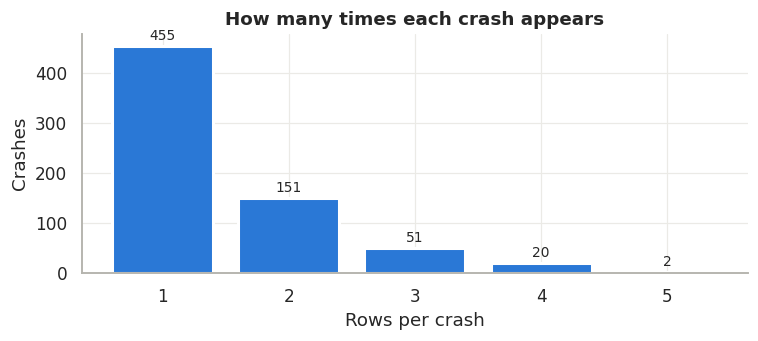

```python
ROADWAY_COLS = ["LANE_COUNT", "SPEED_LIMIT"]
CRASH_COLS = [c for c in df.columns if c not in ROADWAY_COLS]

def same_crash(i, j):
    a, b = df.loc[i, CRASH_COLS], df.loc[j, CRASH_COLS]
    both = a.notna() & b.notna()
    return both.sum() >= 60 and (a[both] == b[both]).all()

crash_id = [0]
for i in range(1, len(df)):
    crash_id.append(crash_id[-1] if same_crash(i - 1, i) else crash_id[-1] + 1)
df["CRASH_ID"] = crash_id

sizes = df.groupby("CRASH_ID").size()
multi = df[df.CRASH_ID.isin(sizes[sizes > 1].index)]
evidence = pd.DataFrame({
    "Value": [len(df), df.CRASH_ID.nunique(), int((sizes > 1).sum()),
              int((multi.groupby("CRASH_ID")["TIME_OF_DAY"].nunique() > 1).sum()),
              int((multi.groupby("CRASH_ID")[ROADWAY_COLS].nunique().max(axis=1) > 1).sum())]},
    index=["Rows", "Distinct crashes", "Crashes recorded more than once",
           "…of which have conflicting TIME_OF_DAY (should be 0)",
           "…of which differ in SPEED_LIMIT / LANE_COUNT (multiple roads)"])
display(evidence)

fig, ax = plt.subplots(figsize=(7, 3.2))
vc = sizes.value_counts().sort_index()
ax.bar(vc.index.astype(str), vc.values, color=C_ALL, edgecolor="white", linewidth=2)
ax.bar_label(ax.containers[0], padding=2, fontsize=9)
ax.set_xlabel("Rows per crash"); ax.set_ylabel("Crashes"); ax.set_title("How many times each crash appears")
plt.tight_layout(); plt.show()
```

```python
# One row per crash: take the first non-missing value of every crash field;
# for the roadway fields take the MAX (the fastest / widest road involved, the relevant one for crash energy)
agg = {c: "first" for c in CRASH_COLS}
agg.update({"SPEED_LIMIT": "max", "LANE_COUNT": "max"})
crash = df.groupby("CRASH_ID").agg(agg).reset_index(drop=True)

before_after = pd.DataFrame({
    "Rows before": [len(df), int(df[TARGET].sum()), int(df.RURAL.sum()), int((df.RURAL * df[TARGET]).sum())],
    "Crashes after": [len(crash), int(crash[TARGET].sum()), int(crash.RURAL.sum()), int((crash.RURAL * crash[TARGET]).sum())]},
    index=["All", "Fatal / serious injury", "Rural", "Rural AND fatal / serious"])
before_after["Severe rate"] = ""
before_after.loc["All", "Severe rate"] = f"{df[TARGET].mean():.1%} → {crash[TARGET].mean():.1%}"
before_after.loc["Rural", "Severe rate"] = f"{df.loc[df.RURAL == 1, TARGET].mean():.1%} → {crash.loc[crash.RURAL == 1, TARGET].mean():.1%}"
before_after
```

|  | Rows before | Crashes after | Severe rate |
| --- | --- | --- | --- |
| All | 1000 | 679 | 5.1% → 5.3% |
| Fatal / serious injury | 51 | 36 |  |
| Rural | 222 | 177 | 5.9% → 6.2% |
| Rural AND fatal / serious | 13 | 11 |  |

### 2c. Missing values: rebuild what can be rebuilt

About 16 columns have ~20% randomly scattered gaps. Several of them are **calculated flags whose source fields are complete**, so they can be rebuilt exactly. Each rule is checked against every cell where the flag is known:

| Flag | Rebuilt from | Dictionary basis |
| --- | --- | --- |
| `WET_ROAD` | `ROAD_CONDITION` is 08 (Water) or 09 (Wet) | Roadway surface condition codes |
| `YOUNG_DRIVER` | any `DRIVER_COUNT_16YR` … `_20YR` > 0 | "at least 1 driver age 16–20" |
| `DRIVER_20YR` | `DRIVER_COUNT_20YR` > 0 | "at least one driver 20 years of age" |
| `DRIVER_50_64YR` | `DRIVER_COUNT_50_64YR` > 0 | "at least one driver 50–64" |
| `MULTIPLE_VEHICLE` | `VEHICLE_COUNT` ≥ 2 | "crash involved at least 2 vehicles" |

Rebuilt flags: validation against known values

| Flag | Missing before | Known cells tested | Rule agrees |
| --- | --- | --- | --- |
| WET_ROAD | 83 | 596 | 100.0% |
| YOUNG_DRIVER | 109 | 570 | 99.6% |
| DRIVER_20YR | 146 | 533 | 100.0% |
| DRIVER_50_64YR | 146 | 533 | 100.0% |
| MULTIPLE_VEHICLE | 96 | 583 | 100.0% |

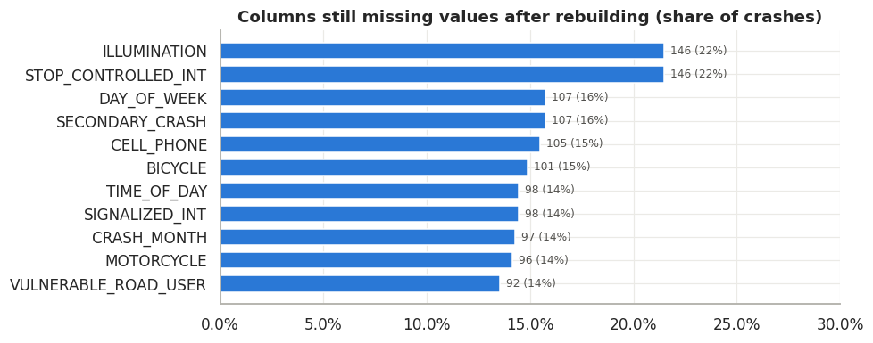

```python
RULES = {
    "WET_ROAD":         crash["ROAD_CONDITION"].isin([8, 9]),
    "YOUNG_DRIVER":     crash[[f"DRIVER_COUNT_{a}YR" for a in range(16, 21)]].sum(axis=1) > 0,
    "DRIVER_20YR":      crash["DRIVER_COUNT_20YR"] > 0,
    "DRIVER_50_64YR":   crash["DRIVER_COUNT_50_64YR"] > 0,
    "MULTIPLE_VEHICLE": crash["VEHICLE_COUNT"] >= 2,
}
rows = []
for col, rule in RULES.items():
    rule = rule.astype(float)
    known = crash[col].notna()
    rows.append({"Flag": col, "Missing before": int((~known).sum()), "Known cells tested": int(known.sum()),
                 "Rule agrees": f"{(rule[known] == crash.loc[known, col]).mean():.1%}"})
    crash[col] = crash[col].fillna(rule)
display(pd.DataFrame(rows).set_index("Flag").style.set_caption("Rebuilt flags: validation against known values"))

miss = crash.isna().sum()
miss = miss[miss > 0].sort_values(ascending=False)
fig, ax = plt.subplots(figsize=(9, 3.6))
ax.barh(miss.index[::-1], miss.values[::-1] / len(crash), color=C_ALL, edgecolor="white", height=0.7)
for i, v in enumerate(miss.values[::-1]):
    ax.text(v / len(crash) + 0.003, i, f"{v} ({v / len(crash):.0%})", va="center", fontsize=8, color="#52514e")
ax.xaxis.set_major_formatter(mtick.PercentFormatter(1)); ax.set_xlim(0, 0.3)
ax.set_title("Columns still missing values after rebuilding (share of crashes)")
plt.tight_layout(); plt.show()
```

**How the remaining gaps are handled**

- `TIME_OF_DAY` and `ILLUMINATION` **duplicate complete columns** (`HOUR_OF_DAY` and `ILLUMINATION_DARK`), so they are dropped.
- `CRASH_MONTH` and `DAY_OF_WEEK` are calendar fields with no direct injury mechanism and are excluded in section 3.
- Any other gap that remains in a feature used by the model is filled with the **training-fold mean** inside the model pipeline. The earlier missing-data notebook found mean imputation to be the least biased simple method, and computing the mean inside each fold avoids leakage.

### 2d. Other data-quality checks

```python
NOT_FLAGS = {"COLLISION_TYPE", "COUNTY", "CRASH_MONTH", "DAY_OF_WEEK", "HOUR_OF_DAY", "ILLUMINATION", "ROAD_CONDITION",
             "TIME_OF_DAY", "URBAN_AREA", "URBAN_RURAL", "LANE_COUNT", "SPEED_LIMIT", "TOTAL_UNITS"}
FLAG_COLS = [c for c in crash.columns if "COUNT" not in c and c not in NOT_FLAGS]
checks = pd.DataFrame([
    ("URBAN_RURAL code 4", int((crash.URBAN_RURAL == 4).sum()), "Not defined in the dictionary (only 1–3). RURAL flag is used instead (it equals URBAN_RURAL == 1 exactly)."),
    ("URBAN_AREA", int(crash.URBAN_AREA.notna().sum()), "Not documented in the dictionary, so dropped."),
    ("PERSON_COUNT = 0", int((crash.PERSON_COUNT == 0).sum()), "Implausible (every crash has a driver). Not used by the final model."),
    ("PERSON_COUNT = 48", int((crash.PERSON_COUNT == 48).sum()), "Real school-bus crash, kept. Not used by the final model."),
    ("SPEED_LIMIT outside 10–70", int((~crash.SPEED_LIMIT.between(10, 70)).sum()), "All values plausible."),
    ("REAR_END flag vs COLLISION_TYPE = 1", int((crash.REAR_END != (crash.COLLISION_TYPE == 1)).sum()), "Disagreements (should be 0)."),
    ("Yes/no flags with values other than 0/1", int(sum((~crash[c].dropna().isin([0, 1])).any() for c in FLAG_COLS)),
     f"Checked all {len(FLAG_COLS)} yes/no flag columns. Should be 0."),
], columns=["Check", "Crashes affected", "Finding / action"]).set_index("Check")
checks
```

| Check | Crashes affected | Finding / action |
| --- | --- | --- |
| URBAN_RURAL code 4 | 421 | Not defined in the dictionary (only 1–3). RURA... |
| URBAN_AREA | 679 | Not documented in the dictionary, so dropped. |
| PERSON_COUNT = 0 | 2 | Implausible (every crash has a driver). Not us... |
| PERSON_COUNT = 48 | 1 | Real school-bus crash, kept. Not used by the f... |
| SPEED_LIMIT outside 10–70 | 0 | All values plausible. |
| REAR_END flag vs COLLISION_TYPE = 1 | 0 | Disagreements (should be 0). |
| Yes/no flags with values other than 0/1 | 0 | Checked all 52 yes/no flag columns. Should be 0. |

```python
# Engineer collision-type indicators from the COLLISION_TYPE code (dictionary: 0 non-collision, 2 head-on, 4 angle, 7 hit fixed object)
crash["NON_COLLISION"] = (crash.COLLISION_TYPE == 0).astype(float)
crash["HEAD_ON"] = (crash.COLLISION_TYPE == 2).astype(float)
crash["ANGLE"] = (crash.COLLISION_TYPE == 4).astype(float)
crash["HIT_FIXED_OBJECT"] = (crash.COLLISION_TYPE == 7).astype(float)
crash["SIDESWIPE"] = crash.COLLISION_TYPE.isin([5, 6]).astype(float)

y = crash[TARGET].astype(int).values
is_rural = (crash.RURAL == 1).values
print(f"Clean dataset: {len(crash)} crashes, {y.sum()} fatal/serious ({y.mean():.1%}); "
      f"rural: {is_rural.sum()} crashes, {y[is_rural].sum()} fatal/serious ({y[is_rural].mean():.1%})")
```

```
Clean dataset: 679 crashes, 36 fatal/serious (5.3%); rural: 177 crashes, 11 fatal/serious (6.2%)
```

## 3. Feature selection, step 1: first principles

Crash severity comes down to **how much energy reaches a human body, and how well that body tolerates it**. That gives a short list of mechanisms. Every column is assigned to one, or rejected if it has no direct mechanism:

| Mechanism | Reasoning | Example columns |
| --- | --- | --- |
| **Energy / speed** | Kinetic energy grows with speed², so faster crashes transfer more energy | `SPEEDING`, `SPEED_LIMIT`, `INTERSTATE` |
| **Unprotected road user** | Motorcyclists and pedestrians have no crash structure, belts or airbags | `MOTORCYCLE`, `PEDESTRIAN`, `BICYCLE` |
| **Crash geometry** | Head-on and side impacts have high closing speeds and little crush space; rear-ends do not | `REAR_END`, `HEAD_ON`, `ANGLE`, `NON_COLLISION` |
| **Driver impairment & behavior** | Impaired, aggressive or distracted driving changes speeds, reaction times and crash types | `IMPAIRED_DRIVER`, `AGGRESSIVE_DRIVING`, `DISTRACTED` |
| **Occupant frailty / inexperience** | Older bodies tolerate less force; young drivers misjudge risk | `DRIVER_75PLUS`, `YOUNG_DRIVER` |
| **Environment** | Darkness and surface conditions change visibility, speed and friction | `ILLUMINATION_DARK`, `WET_ROAD`, `ICY_ROAD` |
| **Road setting** | Road class and traffic control shape speeds and conflicts | `STATE_ROAD`, `INTERSECTION`, `WORK_ZONE` |
| **Vehicle mix / exposure** | Heavier vehicles and more people raise the chance of a severe outcome | `HEAVY_TRUCK_COUNT`, `PERSON_COUNT`, `VEHICLE_COUNT` |

**Rejected** (no injury mechanism, an administrative field, or a duplicate of another column): county, month, day of week, the undocumented `URBAN_AREA`, and duplicated codes. `RURAL` is also not a candidate predictor, because it is the *lens* we analyze through: on rural roads it is constant, so it cannot explain which rural crashes become severe. **Leakage check:** no remaining column records the injury outcome itself (e.g. `INJURY_COUNT`, `FATAL_COUNT`), so none of them leaks the answer.

```python
MECHANISM = {
    "Energy / speed": ["SPEEDING", "SPEED_LIMIT", "LIMIT_65MPH", "LIMIT_70MPH", "INTERSTATE", "LANE_COUNT"],
    "Unprotected road user": ["MOTORCYCLE", "PEDESTRIAN", "PED_COUNT", "BICYCLE", "VULNERABLE_ROAD_USER"],
    "Crash geometry": ["REAR_END", "HEAD_ON", "ANGLE", "SIDESWIPE", "HIT_FIXED_OBJECT", "NON_COLLISION", "SINGLE_VEHICLE",
                       "MULTIPLE_VEHICLE", "LEFT_TURN", "DEER_RELATED", "SUDDEN_DEER", "SECONDARY_CRASH"],
    "Driver impairment & behavior": ["IMPAIRED_DRIVER", "ALCOHOL_RELATED", "DRINKING_DRIVER", "DRUG_RELATED",
                                     "ILLEGAL_DRUG_RELATED", "MARIJUANA_RELATED", "AGGRESSIVE_DRIVING", "DISTRACTED",
                                     "CELL_PHONE", "FATIGUE_ASLEEP", "RUNNING_RED_LT", "RUNNING_STOP_SIGN"],
    "Occupant frailty / inexperience": ["DRIVER_75PLUS", "DRIVER_COUNT_75PLUS", "DRIVER_65_74YR", "DRIVER_COUNT_65_74YR",
                                        "MATURE_DRIVER", "DRIVER_50_64YR", "DRIVER_COUNT_50_64YR", "YOUNG_DRIVER",
                                        "DRIVER_16YR", "DRIVER_17YR", "DRIVER_18YR", "DRIVER_19YR", "DRIVER_20YR",
                                        "DRIVER_COUNT_16YR", "DRIVER_COUNT_17YR", "DRIVER_COUNT_18YR",
                                        "DRIVER_COUNT_19YR", "DRIVER_COUNT_20YR"],
    "Environment": ["ILLUMINATION_DARK", "WET_ROAD", "ICY_ROAD", "SNOW_SLUSH_ROAD", "HOUR_OF_DAY"],
    "Road setting": ["STATE_ROAD", "LOCAL_ROAD", "INTERSECTION", "SIGNALIZED_INT", "STOP_CONTROLLED_INT",
                     "WORK_ZONE", "WORK_ZONE_IND", "SCHOOL_ZONE"],
    "Vehicle mix / exposure": ["HEAVY_TRUCK_COUNT", "SMALL_TRUCK_COUNT", "BUS_COUNT", "SCHOOL_BUS", "PERSON_COUNT",
                               "VEHICLE_COUNT", "TOTAL_UNITS"],
}
REJECTED = {
    "COUNTY": "Administrative code (67 levels), no mechanism", "CRASH_MONTH": "Calendar field, no direct mechanism; 14% missing",
    "DAY_OF_WEEK": "Calendar field, no direct mechanism; 16% missing", "URBAN_AREA": "Not documented in the dictionary",
    "URBAN_RURAL": "Duplicate of RURAL (code 4 undefined)", "RURAL": "The analysis lens: constant on rural roads",
    "TIME_OF_DAY": "Duplicate of HOUR_OF_DAY", "ILLUMINATION": "Duplicate of ILLUMINATION_DARK",
    "ROAD_CONDITION": "Encoded by WET_ROAD / ICY_ROAD / SNOW_SLUSH_ROAD", "COLLISION_TYPE": "Encoded by REAR_END / HEAD_ON / ANGLE / …",
    "AUTOMOBILE_COUNT": "A proxy for vehicle mix (fewer cars = more motorcycles / pedestrians), not a mechanism of its own",
}
mech_of = {c: m for m, cols in MECHANISM.items() for c in cols}
assert set(mech_of) | set(REJECTED) | {TARGET} >= set(crash.columns), set(crash.columns) - set(mech_of) - set(REJECTED)

screen = pd.DataFrame({"Columns kept": {m: len(c) for m, c in MECHANISM.items()}})
screen.loc["Rejected"] = len(REJECTED)
display(screen.T)
display(pd.Series(REJECTED, name="Reason").to_frame().rename_axis("Rejected column"))
CANDIDATES = [c for c in mech_of if crash[c].nunique() > 1]
print(f"{len(CANDIDATES)} candidate features pass the first-principles screen")
```

|  | Energy / speed | Unprotected road user | Crash geometry | Driver impairment & behavior | Occupant frailty / inexperience | Environment | Road setting | Vehicle mix / exposure | Rejected |
| --- | --- | --- | --- | --- | --- | --- | --- | --- | --- |
| Columns kept | 6 | 5 | 12 | 12 | 18 | 5 | 8 | 7 | 11 |

| Rejected column | Reason |
| --- | --- |
| COUNTY | Administrative code (67 levels), no mechanism |
| CRASH_MONTH | Calendar field, no direct mechanism; 14% missing |
| DAY_OF_WEEK | Calendar field, no direct mechanism; 16% missing |
| URBAN_AREA | Not documented in the dictionary |
| URBAN_RURAL | Duplicate of RURAL (code 4 undefined) |
| RURAL | The analysis lens: constant on rural roads |
| TIME_OF_DAY | Duplicate of HOUR_OF_DAY |
| ILLUMINATION | Duplicate of ILLUMINATION_DARK |
| ROAD_CONDITION | Encoded by WET_ROAD / ICY_ROAD / SNOW_SLUSH_ROAD |
| COLLISION_TYPE | Encoded by REAR_END / HEAD_ON / ANGLE / … |
| AUTOMOBILE_COUNT | A proxy for vehicle mix (fewer cars = more mot... |

```
73 candidate features pass the first-principles screen
```

## 4. Feature selection, step 2: a simple filter

Each candidate is tested **on its own** against the outcome, with no model involved:

- **0/1 flags:** the severe rate when the flag is yes vs. no, as a **risk ratio** (RR = rate if yes ÷ rate if no), with **Fisher's exact test** (suitable for small counts).
- **Counts and numbers** (`SPEED_LIMIT`, `PERSON_COUNT`, …): a **Mann–Whitney** test comparing severe and non-severe crashes.

Each test is run twice: on **all crashes** and on **rural crashes only**. A feature **passes the filter** if it is exposed in at least 15 crashes and has p < 0.20 in either group. The threshold is loose on purpose: this is a screening step, and with only 36 severe crashes a strict cut-off would discard real effects.

```python
def univariate(d, col):
    s, t = d[col], d[TARGET]
    ok = s.notna()
    if crash[col].dropna().isin([0, 1]).all():
        a = int(((s == 1) & (t == 1)).sum()); n1 = int((s == 1).sum())
        b = int(((s == 0) & (t == 1)).sum()); n0 = int((s == 0).sum())
        if n1 == 0 or n0 == 0:
            return dict(n_exposed=n1, severe_exposed=a, rate_yes=np.nan, rate_no=np.nan, RR=np.nan, p=np.nan)
        p = fisher_exact([[a, n1 - a], [b, n0 - b]])[1]
        rr = (a / n1) / (b / n0) if b else np.nan
        return dict(n_exposed=n1, severe_exposed=a, rate_yes=a / n1, rate_no=b / n0, RR=rr, p=p)
    p = mannwhitneyu(s[ok & (t == 1)], s[ok & (t == 0)])[1]
    return dict(n_exposed=int(ok.sum()), severe_exposed=int(t[ok].sum()), rate_yes=s[ok & (t == 1)].mean(),
                rate_no=s[ok & (t == 0)].mean(), RR=np.nan, p=p)

rural_crash = crash[crash.RURAL == 1]
flt = pd.concat({
    "All crashes": pd.DataFrame({c: univariate(crash, c) for c in CANDIDATES}).T,
    "Rural crashes": pd.DataFrame({c: univariate(rural_crash, c) for c in CANDIDATES}).T}, axis=1)
flt.insert(0, ("", "Mechanism"), [mech_of[c] for c in flt.index])
flt[("", "Passes filter")] = ((flt[("All crashes", "n_exposed")] >= 15) &
                              ((flt[("All crashes", "p")] < 0.20) | (flt[("Rural crashes", "p")] < 0.20)))
flt = flt.sort_values(("All crashes", "p"))

def fmt_rr(v): return "" if pd.isna(v) else ("0 severe" if v == 0 else f"{v:.2f}")

is_flag = {c: crash[c].dropna().isin([0, 1]).all() for c in flt.index}
def fmt_rate(v, c): return "" if pd.isna(v) else (f"{v:.1%}" if is_flag[c] else f"mean {v:.2f}")
show = pd.DataFrame(index=flt.index)
show["Mechanism"] = flt[("", "Mechanism")]
for scope in ["All crashes", "Rural crashes"]:
    show[(scope, "Exposed (yes)")] = [f"{int(flt.loc[c, (scope, 'n_exposed')])}" if is_flag[c] else "numeric" for c in flt.index]
    show[(scope, "Severe if yes")] = [fmt_rate(flt.loc[c, (scope, "rate_yes")], c) for c in flt.index]
    show[(scope, "Severe if no")] = [fmt_rate(flt.loc[c, (scope, "rate_no")], c) for c in flt.index]
    show[(scope, "Risk ratio")] = flt[(scope, "RR")].map(fmt_rr)
    show[(scope, "p")] = flt[(scope, "p")].astype(float)
show["Passes filter"] = flt[("", "Passes filter")].map({True: "✔ yes", False: ""})
show.columns = pd.MultiIndex.from_tuples([c if isinstance(c, tuple) else ("", c) for c in show.columns])
(show.style.format("{:.3f}", subset=[c for c in show.columns if c[1] == "p"], na_rep="")
     .map(lambda v: "background-color: #f4c7c3" if v < 0.05 else ("background-color: #fbe5d6" if v < 0.20 else ""),
          subset=[c for c in show.columns if c[1] == "p"])
     .map(lambda v: "font-weight: bold; color: #1c5cab" if v else "", subset=[("", "Passes filter")])
     .set_caption("Univariate filter for every candidate, sorted by all-crash p-value. For numeric features "
                  "('mean'), the two rate columns show the mean in severe vs. non-severe crashes"))
```

Univariate filter for every candidate, sorted by all-crash p-value. For numeric features ('mean'), the two rate columns show the mean in severe vs. non-severe crashes

|  | Mechanism | All crashes Exposed (yes) | All crashes Severe if yes | All crashes Severe if no | All crashes Risk ratio | All crashes p | Rural crashes Exposed (yes) | Rural crashes Severe if yes | Rural crashes Severe if no | Rural crashes Risk ratio | Rural crashes p | Passes filter |
| --- | --- | --- | --- | --- | --- | --- | --- | --- | --- | --- | --- | --- |
| REAR_END | Crash geometry | 127 | 0.0% | 6.5% | 0 severe | 0.001 | 19 | 0.0% | 7.0% | 0 severe | 0.611 | ✔ yes |
| MOTORCYCLE | Unprotected road user | 21 | 28.6% | 5.0% | 5.73 | 0.001 | 4 | 50.0% | 5.7% | 8.81 | 0.024 | ✔ yes |
| AGGRESSIVE_DRIVING | Driver impairment & behavior | 357 | 7.3% | 3.1% | 2.35 | 0.016 | 89 | 10.1% | 2.3% | 4.45 | 0.057 | ✔ yes |
| SPEEDING | Energy / speed | 20 | 20.0% | 4.9% | 4.12 | 0.018 | 5 | 40.0% | 5.2% | 7.64 | 0.032 | ✔ yes |
| DISTRACTED | Driver impairment & behavior | 70 | 0.0% | 5.9% | 0 severe | 0.042 | 9 | 0.0% | 6.5% | 0 severe | 1.000 | ✔ yes |
| IMPAIRED_DRIVER | Driver impairment & behavior | 53 | 11.3% | 4.8% | 2.36 | 0.053 | 12 | 16.7% | 5.5% | 3.06 | 0.165 | ✔ yes |
| ALCOHOL_RELATED | Driver impairment & behavior | 42 | 11.9% | 4.9% | 2.45 | 0.064 | 11 | 18.2% | 5.4% | 3.35 | 0.142 | ✔ yes |
| DRINKING_DRIVER | Driver impairment & behavior | 42 | 11.9% | 4.9% | 2.45 | 0.064 | 11 | 18.2% | 5.4% | 3.35 | 0.142 | ✔ yes |
| RUNNING_STOP_SIGN | Driver impairment & behavior | 18 | 16.7% | 5.0% | 3.34 | 0.064 | 6 | 0.0% | 6.4% | 0 severe | 1.000 | ✔ yes |
| DRIVER_COUNT_75PLUS | Occupant frailty / inexperience | numeric | mean 0.17 | mean 0.09 |  | 0.083 | numeric | mean 0.18 | mean 0.08 |  | 0.279 | ✔ yes |
| NON_COLLISION | Crash geometry | 20 | 15.0% | 5.0% | 3.00 | 0.084 | 10 | 10.0% | 6.0% | 1.67 | 0.483 | ✔ yes |
| DEER_RELATED | Crash geometry | 49 | 0.0% | 5.7% | 0 severe | 0.100 | 29 | 0.0% | 7.4% | 0 severe | 0.215 | ✔ yes |
| SUDDEN_DEER | Crash geometry | 48 | 0.0% | 5.7% | 0 severe | 0.101 | 28 | 0.0% | 7.4% | 0 severe | 0.217 | ✔ yes |
| LEFT_TURN | Crash geometry | 86 | 9.3% | 4.7% | 1.97 | 0.115 | 16 | 12.5% | 5.6% | 2.24 | 0.260 | ✔ yes |
| DRIVER_75PLUS | Occupant frailty / inexperience | 59 | 10.2% | 4.8% | 2.10 | 0.117 | 16 | 12.5% | 5.6% | 2.24 | 0.260 | ✔ yes |
| RUNNING_RED_LT | Driver impairment & behavior | 24 | 12.5% | 5.0% | 2.48 | 0.129 | 4 | 25.0% | 5.8% | 4.33 | 0.228 | ✔ yes |
| LIMIT_70MPH | Energy / speed | 41 | 0.0% | 5.6% | 0 severe | 0.158 | 24 | 0.0% | 7.2% | 0 severe | 0.365 | ✔ yes |
| ILLUMINATION_DARK | Environment | 163 | 3.1% | 6.0% | 0.51 | 0.165 | 46 | 0.0% | 8.4% | 0 severe | 0.069 | ✔ yes |
| ANGLE | Crash geometry | 176 | 7.4% | 4.6% | 1.62 | 0.171 | 38 | 7.9% | 5.8% | 1.37 | 0.704 | ✔ yes |
| VEHICLE_COUNT | Vehicle mix / exposure | numeric | mean 1.53 | mean 1.71 |  | 0.180 | numeric | mean 1.36 | mean 1.43 |  | 0.849 | ✔ yes |
| SECONDARY_CRASH | Crash geometry | 20 | 10.0% | 4.3% | 2.30 | 0.229 | 1 | 100.0% | 6.1% | 16.33 | 0.068 | ✔ yes |
| TOTAL_UNITS | Vehicle mix / exposure | numeric | mean 1.58 | mean 1.75 |  | 0.244 | numeric | mean 1.36 | mean 1.44 |  | 0.790 |  |
| VULNERABLE_ROAD_USER | Unprotected road user | 20 | 10.0% | 4.8% | 2.10 | 0.259 | 0 |  |  |  |  |  |
| PEDESTRIAN | Unprotected road user | 19 | 10.5% | 5.2% | 2.04 | 0.267 | 0 |  |  |  |  |  |
| ILLEGAL_DRUG_RELATED | Driver impairment & behavior | 19 | 10.5% | 5.2% | 2.04 | 0.267 | 4 | 25.0% | 5.8% | 4.33 | 0.228 |  |
| PED_COUNT | Unprotected road user | 19 | 10.5% | 5.2% | 2.04 | 0.267 | 0 |  |  |  |  |  |
| DRIVER_COUNT_65_74YR | Occupant frailty / inexperience | numeric | mean 0.06 | mean 0.12 |  | 0.270 | numeric | mean 0.00 | mean 0.09 |  | 0.302 |  |
| HIT_FIXED_OBJECT | Crash geometry | 222 | 6.8% | 4.6% | 1.47 | 0.274 | 76 | 7.9% | 5.0% | 1.59 | 0.533 |  |
| MARIJUANA_RELATED | Driver impairment & behavior | 6 | 16.7% | 5.2% | 3.20 | 0.280 | 3 | 33.3% | 5.7% | 5.80 | 0.176 |  |
| DRUG_RELATED | Driver impairment & behavior | 20 | 10.0% | 5.2% | 1.94 | 0.287 | 5 | 20.0% | 5.8% | 3.44 | 0.277 |  |
| SINGLE_VEHICLE | Crash geometry | 296 | 6.4% | 4.4% | 1.45 | 0.301 | 111 | 6.3% | 6.1% | 1.04 | 1.000 |  |
| MULTIPLE_VEHICLE | Crash geometry | 383 | 4.4% | 6.4% | 0.69 | 0.301 | 66 | 6.1% | 6.3% | 0.96 | 1.000 |  |
| STOP_CONTROLLED_INT | Road setting | 65 | 1.5% | 5.3% | 0.29 | 0.350 | 17 | 0.0% | 7.1% | 0 severe | 0.602 |  |
| INTERSTATE | Energy / speed | 74 | 2.7% | 5.6% | 0.48 | 0.413 | 28 | 0.0% | 7.4% | 0 severe | 0.217 |  |
| DRIVER_65_74YR | Occupant frailty / inexperience | 76 | 2.6% | 5.6% | 0.47 | 0.414 | 15 | 0.0% | 6.8% | 0 severe | 0.602 |  |
| LOCAL_ROAD | Road setting | 262 | 6.1% | 4.8% | 1.27 | 0.484 | 34 | 11.8% | 4.9% | 2.40 | 0.226 |  |
| DRIVER_COUNT_16YR | Occupant frailty / inexperience | numeric | mean 0.00 | mean 0.01 |  | 0.503 | numeric | mean 0.00 | mean 0.01 |  | 0.727 |  |
| LIMIT_65MPH | Energy / speed | 47 | 2.1% | 5.5% | 0.38 | 0.503 | 21 | 0.0% | 7.1% | 0 severe | 0.366 |  |
| WORK_ZONE | Road setting | 14 | 7.1% | 5.3% | 1.36 | 0.537 | 4 | 0.0% | 6.4% | 0 severe | 1.000 |  |
| WORK_ZONE_IND | Road setting | 14 | 7.1% | 5.3% | 1.36 | 0.537 | 4 | 0.0% | 6.4% | 0 severe | 1.000 |  |
| SMALL_TRUCK_COUNT | Vehicle mix / exposure | numeric | mean 0.11 | mean 0.15 |  | 0.538 | numeric | mean 0.09 | mean 0.19 |  | 0.425 |  |
| FATIGUE_ASLEEP | Driver impairment & behavior | 16 | 6.2% | 5.3% | 1.18 | 0.586 | 6 | 0.0% | 6.4% | 0 severe | 1.000 |  |
| DRIVER_COUNT_17YR | Occupant frailty / inexperience | 21 | 0.0% | 5.5% | 0 severe | 0.620 | 4 | 0.0% | 6.4% | 0 severe | 1.000 |  |
| DRIVER_17YR | Occupant frailty / inexperience | 21 | 0.0% | 5.5% | 0 severe | 0.620 | 4 | 0.0% | 6.4% | 0 severe | 1.000 |  |
| LANE_COUNT | Energy / speed | numeric | mean 2.25 | mean 2.29 |  | 0.629 | numeric | mean 2.00 | mean 2.14 |  | 0.422 |  |
| HEAD_ON | Crash geometry | 30 | 6.7% | 5.2% | 1.27 | 0.669 | 4 | 25.0% | 5.8% | 4.33 | 0.228 |  |
| DRIVER_19YR | Occupant frailty / inexperience | 31 | 6.5% | 5.2% | 1.23 | 0.677 | 8 | 0.0% | 6.5% | 0 severe | 1.000 |  |
| DRIVER_COUNT_19YR | Occupant frailty / inexperience | 31 | 6.5% | 5.2% | 1.23 | 0.677 | 8 | 0.0% | 6.5% | 0 severe | 1.000 |  |
| DRIVER_COUNT_18YR | Occupant frailty / inexperience | numeric | mean 0.03 | mean 0.04 |  | 0.705 | numeric | mean 0.00 | mean 0.05 |  | 0.463 |  |
| DRIVER_50_64YR | Occupant frailty / inexperience | 189 | 5.8% | 5.1% | 1.14 | 0.705 | 50 | 10.0% | 4.7% | 2.12 | 0.297 |  |
| DRIVER_COUNT_20YR | Occupant frailty / inexperience | numeric | mean 0.03 | mean 0.04 |  | 0.705 | numeric | mean 0.00 | mean 0.05 |  | 0.434 |  |
| DRIVER_COUNT_50_64YR | Occupant frailty / inexperience | numeric | mean 0.33 | mean 0.31 |  | 0.742 | numeric | mean 0.55 | mean 0.28 |  | 0.152 | ✔ yes |
| PERSON_COUNT | Vehicle mix / exposure | numeric | mean 2.17 | mean 2.18 |  | 0.759 | numeric | mean 1.64 | mean 2.11 |  | 0.797 |  |
| SIGNALIZED_INT | Road setting | 72 | 5.6% | 4.9% | 1.13 | 0.773 | 7 | 14.3% | 3.8% | 3.80 | 0.269 |  |
| HOUR_OF_DAY | Environment | numeric | mean 13.64 | mean 13.25 |  | 0.806 | numeric | mean 15.45 | mean 13.48 |  | 0.283 |  |
| YOUNG_DRIVER | Occupant frailty / inexperience | 111 | 4.5% | 5.5% | 0.83 | 0.819 | 30 | 0.0% | 7.5% | 0 severe | 0.215 |  |
| STATE_ROAD | Road setting | 523 | 5.2% | 5.8% | 0.89 | 0.839 | 154 | 5.2% | 13.0% | 0.40 | 0.157 | ✔ yes |
| INTERSECTION | Road setting | 239 | 5.0% | 5.5% | 0.92 | 0.860 | 39 | 7.7% | 5.8% | 1.33 | 0.709 |  |
| SPEED_LIMIT | Energy / speed | numeric | mean 40.83 | mean 41.93 |  | 0.937 | numeric | mean 41.82 | mean 49.37 |  | 0.081 | ✔ yes |
| HEAVY_TRUCK_COUNT | Vehicle mix / exposure | numeric | mean 0.08 | mean 0.09 |  | 0.996 | numeric | mean 0.00 | mean 0.13 |  | 0.285 |  |
| CELL_PHONE | Driver impairment & behavior | 3 | 0.0% | 5.1% | 0 severe | 1.000 | 0 |  |  |  |  |  |
| DRIVER_18YR | Occupant frailty / inexperience | 27 | 3.7% | 5.4% | 0.69 | 1.000 | 8 | 0.0% | 6.5% | 0 severe | 1.000 |  |
| BICYCLE | Unprotected road user | 2 | 0.0% | 5.4% | 0 severe | 1.000 | 0 |  |  |  |  |  |
| SIDESWIPE | Crash geometry | 35 | 2.9% | 5.4% | 0.53 | 1.000 | 2 | 0.0% | 6.3% | 0 severe | 1.000 |  |
| SNOW_SLUSH_ROAD | Environment | 5 | 0.0% | 5.3% | 0 severe | 1.000 | 2 | 0.0% | 6.3% | 0 severe | 1.000 |  |
| ICY_ROAD | Environment | 3 | 0.0% | 5.3% | 0 severe | 1.000 | 1 | 0.0% | 6.2% | 0 severe | 1.000 |  |
| WET_ROAD | Environment | 101 | 5.0% | 5.4% | 0.92 | 1.000 | 29 | 13.8% | 4.7% | 2.92 | 0.084 | ✔ yes |
| DRIVER_20YR | Occupant frailty / inexperience | 27 | 3.7% | 5.4% | 0.69 | 1.000 | 9 | 0.0% | 6.5% | 0 severe | 1.000 |  |
| MATURE_DRIVER | Occupant frailty / inexperience | 130 | 5.4% | 5.3% | 1.02 | 1.000 | 31 | 6.5% | 6.2% | 1.05 | 1.000 |  |
| DRIVER_16YR | Occupant frailty / inexperience | 8 | 0.0% | 5.4% | 0 severe | 1.000 | 2 | 0.0% | 6.3% | 0 severe | 1.000 |  |
| SCHOOL_BUS | Vehicle mix / exposure | 7 | 0.0% | 5.4% | 0 severe | 1.000 | 3 | 0.0% | 6.3% | 0 severe | 1.000 |  |
| SCHOOL_ZONE | Road setting | 1 | 0.0% | 5.3% | 0 severe | 1.000 | 0 |  |  |  |  |  |
| BUS_COUNT | Vehicle mix / exposure | 4 | 0.0% | 5.3% | 0 severe | 1.000 | 2 | 0.0% | 6.3% | 0 severe | 1.000 |  |

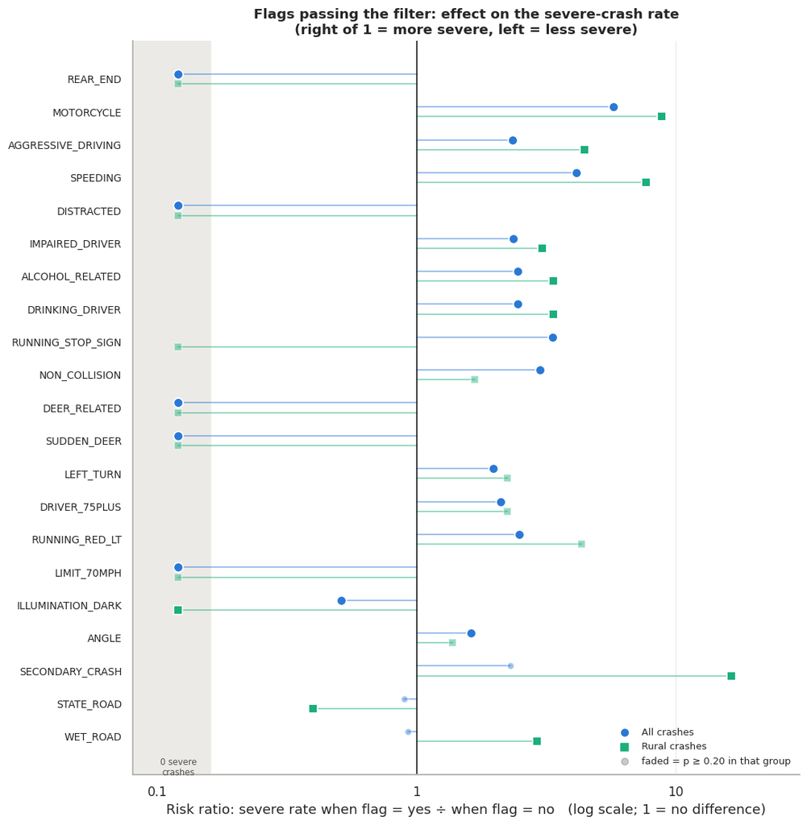

```python
# Visual: risk ratio for every 0/1 candidate that passes the filter, all crashes vs. rural crashes
passing = flt[flt[("", "Passes filter")]]
bin_pass = [c for c in passing.index if not pd.isna(passing.loc[c, ("All crashes", "RR")])]
fig, ax = plt.subplots(figsize=(10, 0.42 * len(bin_pass) + 1.4))
FLOOR = 0.12   # where to draw "0 severe crashes" (RR = 0 has no log position)
for i, c in enumerate(bin_pass):
    for scope, color, dy, marker in [("All crashes", C_ALL, -0.15, "o"), ("Rural crashes", C_RURAL, 0.15, "s")]:
        rr, p = flt.loc[c, (scope, "RR")], flt.loc[c, (scope, "p")]
        if pd.isna(rr):
            continue
        x = max(rr, FLOOR)
        ax.plot([1, x], [i + dy, i + dy], color=color, lw=1.2, alpha=0.5)
        ax.scatter(x, i + dy, s=70 if p < 0.2 else 35, color=color, marker=marker, zorder=3,
                   edgecolor="white", linewidth=1.2, alpha=1 if p < 0.2 else 0.45)
ax.axvline(1, color="#0b0b0b", lw=1)
ax.axvspan(0.08, 0.16, color="#ebeae6", zorder=0)
ax.text(FLOOR, len(bin_pass) - 0.35, "0 severe\ncrashes", ha="center", va="top", fontsize=7.5, color="#52514e")
ax.set_xscale("log"); ax.set_xlim(0.08, 30)
ax.xaxis.set_major_formatter(mtick.FuncFormatter(lambda v, _: f"{v:g}"))
ax.xaxis.set_minor_formatter(mtick.NullFormatter())
ax.set_yticks(range(len(bin_pass)), bin_pass, fontsize=9); ax.invert_yaxis(); ax.grid(axis="y", visible=False)
ax.set_xlabel("Risk ratio: severe rate when flag = yes ÷ when flag = no   (log scale; 1 = no difference)")
ax.scatter([], [], color=C_ALL, marker="o", label="All crashes"); ax.scatter([], [], color=C_RURAL, marker="s", label="Rural crashes")
ax.scatter([], [], color="#8a8986", s=35, alpha=0.45, label="faded = p ≥ 0.20 in that group")
ax.legend(loc="lower right", frameon=False, fontsize=8.5)
ax.set_title("Flags passing the filter: effect on the severe-crash rate\n(right of 1 = more severe, left = less severe)")
plt.tight_layout(); plt.show()
```

## 5. Feature selection, step 3: remove redundancy and choose the final 10

Several flags that pass the filter are **the same information under different names**: one flag is a subset of another, or the two are identical. Keeping both splits one effect across two coefficients and causes multicollinearity. The table below measures the overlap directly, as the share of crashes with flag A that also have flag B.

```python
PAIRS = [("DRINKING_DRIVER", "ALCOHOL_RELATED"), ("DRINKING_DRIVER", "IMPAIRED_DRIVER"),
         ("RUNNING_STOP_SIGN", "AGGRESSIVE_DRIVING"), ("RUNNING_RED_LT", "AGGRESSIVE_DRIVING"),
         ("SPEEDING", "AGGRESSIVE_DRIVING"), ("SUDDEN_DEER", "DEER_RELATED"),
         ("DRIVER_75PLUS", "MATURE_DRIVER"), ("WORK_ZONE", "WORK_ZONE_IND"), ("PEDESTRIAN", "VULNERABLE_ROAD_USER")]
ov = []
for a, b in PAIRS:
    A, B = crash[a] == 1, crash[b] == 1
    ov.append({"Flag A": a, "Flag B": b, "Crashes with A": int(A.sum()), "% of A that are also B": (A & B).sum() / A.sum(),
               "% of B that are also A": (A & B).sum() / B.sum(), "phi correlation": crash[[a, b]].corr().iloc[0, 1]})
(pd.DataFrame(ov).style.format({"% of A that are also B": "{:.0%}", "% of B that are also A": "{:.0%}", "phi correlation": "{:.2f}"})
   .bar(subset=["% of A that are also B"], color="#b7d3f6", vmin=0, vmax=1).hide(axis="index")
   .set_caption("Overlap between related flags"))
```

Overlap between related flags

| Flag A | Flag B | Crashes with A | % of A that are also B | % of B that are also A | phi correlation |
| --- | --- | --- | --- | --- | --- |
| DRINKING_DRIVER | ALCOHOL_RELATED | 42 | 100% | 100% | 1.00 |
| DRINKING_DRIVER | IMPAIRED_DRIVER | 42 | 100% | 79% | 0.88 |
| RUNNING_STOP_SIGN | AGGRESSIVE_DRIVING | 18 | 100% | 5% | 0.16 |
| RUNNING_RED_LT | AGGRESSIVE_DRIVING | 24 | 100% | 7% | 0.18 |
| SPEEDING | AGGRESSIVE_DRIVING | 20 | 100% | 6% | 0.17 |
| SUDDEN_DEER | DEER_RELATED | 48 | 100% | 98% | 0.99 |
| DRIVER_75PLUS | MATURE_DRIVER | 59 | 100% | 45% | 0.63 |
| WORK_ZONE | WORK_ZONE_IND | 14 | 100% | 100% | 1.00 |
| PEDESTRIAN | VULNERABLE_ROAD_USER | 19 | 89% | 85% | 0.92 |

**Redundancy decisions**

- `ALCOHOL_RELATED` = `DRINKING_DRIVER` (identical), and both sit inside `IMPAIRED_DRIVER` → keep the umbrella **`IMPAIRED_DRIVER`**.
- `RUNNING_STOP_SIGN` and `RUNNING_RED_LT` are **100% inside** `AGGRESSIVE_DRIVING` (PennDOT counts them as aggressive actions) → keep **`AGGRESSIVE_DRIVING`**.
- `SPEEDING` is also inside `AGGRESSIVE_DRIVING`, but it is kept as well. It has its own physical mechanism (energy), the strongest filter signal of any behavior, and the multicollinearity check in section 6 shows the pair is fine. With both in the model, `AGGRESSIVE_DRIVING` measures *aggressive actions other than speeding*.
- `SUDDEN_DEER` ≈ `DEER_RELATED` → keep **`DEER_RELATED`**. `DRIVER_COUNT_75PLUS` ≈ `DRIVER_75PLUS` → keep the flag **`DRIVER_75PLUS`**.

**Final pick.** After merging those duplicates, the strongest features (ranked by all-crash p-value) are combined with first-principles strength and rural evidence:

```python
FINAL = ["MOTORCYCLE", "SPEEDING", "AGGRESSIVE_DRIVING", "IMPAIRED_DRIVER", "DRIVER_75PLUS",
         "REAR_END", "DEER_RELATED", "DISTRACTED", "NON_COLLISION", "ILLUMINATION_DARK"]
WHY = {
    "MOTORCYCLE": "Unprotected rider. Strongest signal overall and on rural roads.",
    "SPEEDING": "Crash energy rises with speed squared. Strong signal overall and on rural roads.",
    "AGGRESSIVE_DRIVING": "Risky driver actions (red lights, stop signs, tailgating). Also covers the stop-sign and red-light flags.",
    "IMPAIRED_DRIVER": "Alcohol or drugs: slower reactions, higher speeds. Covers the drinking and alcohol flags.",
    "DRIVER_75PLUS": "Older bodies tolerate less force. Raises risk ~2× overall and on rural roads.",
    "REAR_END": "Same-direction impact, low closing speed: 0 of 127 severe. A strong protective marker.",
    "DEER_RELATED": "A very common rural crash type (60% of deer crashes are rural), 0 of 49 severe. Separates low-risk rural crashes.",
    "DISTRACTED": "Distraction crashes are mostly low-speed (often rear-ends): 0 of 70 severe.",
    "NON_COLLISION": "Rollovers and other non-collision events, mostly single-vehicle: ~3× risk.",
    "ILLUMINATION_DARK": "Lighting is a core mechanism; strongest rural environment signal (p ≈ 0.07). Chosen over LEFT_TURN, whose rural signal is weak.",
}
pick = flt.loc[FINAL]
pick_tbl = pd.DataFrame({
    "Mechanism": pick[("", "Mechanism")],
    "RR all": pick[("All crashes", "RR")].map(fmt_rr), "p all": pick[("All crashes", "p")],
    "RR rural": pick[("Rural crashes", "RR")].map(fmt_rr), "p rural": pick[("Rural crashes", "p")],
    "Crashes exposed (all / rural)": [f"{int(pick.loc[c, ('All crashes', 'n_exposed')])} / {int(pick.loc[c, ('Rural crashes', 'n_exposed')])}" for c in FINAL],
    "Why it was chosen": pd.Series(WHY)})
pick_tbl.index.name = "Selected feature"
(pick_tbl.style.format({"p all": "{:.3f}", "p rural": "{:.3f}"})
   .map(lambda v: "background-color: #f4c7c3" if v < 0.05 else ("background-color: #fbe5d6" if v < 0.20 else ""),
        subset=["p all", "p rural"])
   .set_properties(subset=["Why it was chosen"], **{"text-align": "left", "white-space": "normal"})
   .set_caption("The proposed 10 features"))
```

The proposed 10 features

| Selected feature | Mechanism | RR all | p all | RR rural | p rural | Crashes exposed (all / rural) | Why it was chosen |
| --- | --- | --- | --- | --- | --- | --- | --- |
| MOTORCYCLE | Unprotected road user | 5.73 | 0.001 | 8.81 | 0.024 | 21 / 4 | Unprotected rider. Strongest signal overall and on rural roads. |
| SPEEDING | Energy / speed | 4.12 | 0.018 | 7.64 | 0.032 | 20 / 5 | Crash energy rises with speed squared. Strong signal overall and on rural roads. |
| AGGRESSIVE_DRIVING | Driver impairment & behavior | 2.35 | 0.016 | 4.45 | 0.057 | 357 / 89 | Risky driver actions (red lights, stop signs, tailgating). Also covers the stop-sign and red-light flags. |
| IMPAIRED_DRIVER | Driver impairment & behavior | 2.36 | 0.053 | 3.06 | 0.165 | 53 / 12 | Alcohol or drugs: slower reactions, higher speeds. Covers the drinking and alcohol flags. |
| DRIVER_75PLUS | Occupant frailty / inexperience | 2.10 | 0.117 | 2.24 | 0.260 | 59 / 16 | Older bodies tolerate less force. Raises risk ~2× overall and on rural roads. |
| REAR_END | Crash geometry | 0 severe | 0.001 | 0 severe | 0.611 | 127 / 19 | Same-direction impact, low closing speed: 0 of 127 severe. A strong protective marker. |
| DEER_RELATED | Crash geometry | 0 severe | 0.100 | 0 severe | 0.215 | 49 / 29 | A very common rural crash type (60% of deer crashes are rural), 0 of 49 severe. Separates low-risk rural crashes. |
| DISTRACTED | Driver impairment & behavior | 0 severe | 0.042 | 0 severe | 1.000 | 70 / 9 | Distraction crashes are mostly low-speed (often rear-ends): 0 of 70 severe. |
| NON_COLLISION | Crash geometry | 3.00 | 0.084 | 1.67 | 0.483 | 20 / 10 | Rollovers and other non-collision events, mostly single-vehicle: ~3× risk. |
| ILLUMINATION_DARK | Environment | 0.51 | 0.165 | 0 severe | 0.069 | 163 / 46 | Lighting is a core mechanism; strongest rural environment signal (p ≈ 0.07). Chosen over LEFT_TURN, whose rural signal is weak. |

```python
not_chosen = flt[flt[("", "Passes filter")] & ~flt.index.isin(FINAL)].index
REASON = {"ALCOHOL_RELATED": "Duplicate of DRINKING_DRIVER; inside IMPAIRED_DRIVER", "DRINKING_DRIVER": "Inside IMPAIRED_DRIVER",
          "RUNNING_STOP_SIGN": "100% inside AGGRESSIVE_DRIVING", "RUNNING_RED_LT": "100% inside AGGRESSIVE_DRIVING",
          "SUDDEN_DEER": "Near-duplicate of DEER_RELATED", "DRIVER_COUNT_75PLUS": "Count version of DRIVER_75PLUS",
          "LEFT_TURN": "Weaker than the chosen ten, and weak on rural roads (p_rural ≈ 0.26)",
          "LIMIT_70MPH": "Interstates only (0 severe); does not apply to most rural roads",
          "ANGLE": "Weaker overall (p ≈ 0.17) and very weak on rural roads (p ≈ 0.70)",
          "SECONDARY_CRASH": "Only 1 rural crash exposed; rural p-value rests on a single case",
          "SPEED_LIMIT": "Rural signal points the wrong way (lower limits more severe), likely chance; overlaps SPEEDING",
          "WET_ROAD": "Rural signal only (p ≈ 0.08); no overall signal (RR ≈ 0.9)",
          "STATE_ROAD": "Rural signal only, and points the wrong way (state roads less severe)",
          "DRIVER_COUNT_50_64YR": "Rural signal only; no overall signal",
          "VEHICLE_COUNT": "Weak (p ≈ 0.18); crash geometry is captured more directly by collision type",
          "HOUR_OF_DAY": "Lighting captured more directly by ILLUMINATION_DARK"}
pd.DataFrame({"All-crash p": flt.loc[not_chosen, ("All crashes", "p")].round(3),
              "Rural p": flt.loc[not_chosen, ("Rural crashes", "p")].round(3),
              "Why not in the final 10": [REASON.get(c, "Weaker evidence than the selected ten") for c in not_chosen]}
             ).rename_axis("Passed the filter but not selected")
```

| Passed the filter but not selected | All-crash p | Rural p | Why not in the final 10 |
| --- | --- | --- | --- |
| ALCOHOL_RELATED | 0.064 | 0.142 | Duplicate of DRINKING_DRIVER; inside IMPAIRED_... |
| DRINKING_DRIVER | 0.064 | 0.142 | Inside IMPAIRED_DRIVER |
| RUNNING_STOP_SIGN | 0.064 | 1.000 | 100% inside AGGRESSIVE_DRIVING |
| DRIVER_COUNT_75PLUS | 0.083 | 0.279 | Count version of DRIVER_75PLUS |
| SUDDEN_DEER | 0.101 | 0.217 | Near-duplicate of DEER_RELATED |
| LEFT_TURN | 0.115 | 0.260 | Weaker than the chosen ten, and weak on rural ... |
| RUNNING_RED_LT | 0.129 | 0.228 | 100% inside AGGRESSIVE_DRIVING |
| LIMIT_70MPH | 0.158 | 0.365 | Interstates only (0 severe); does not apply to... |
| ANGLE | 0.171 | 0.704 | Weaker overall (p ≈ 0.17) and very weak on rur... |
| VEHICLE_COUNT | 0.180 | 0.849 | Weak (p ≈ 0.18); crash geometry is captured mo... |
| SECONDARY_CRASH | 0.229 | 0.068 | Only 1 rural crash exposed; rural p-value rest... |
| DRIVER_COUNT_50_64YR | 0.742 | 0.152 | Rural signal only; no overall signal |
| STATE_ROAD | 0.839 | 0.157 | Rural signal only, and points the wrong way (s... |
| SPEED_LIMIT | 0.937 | 0.081 | Rural signal points the wrong way (lower limit... |
| WET_ROAD | 1.000 | 0.084 | Rural signal only (p ≈ 0.08); no overall signa... |

## 6. Multicollinearity check

Two diagnostics:

- **Correlation matrix** (phi coefficient, the Pearson correlation for 0/1 flags). Values above ~0.7 would signal trouble.
- **Variance inflation factor (VIF):** how much a coefficient's variance is inflated by overlap with the other features. Rule of thumb: VIF > 5 is a concern, VIF > 10 a serious problem.

For contrast, we also compute the VIFs for the set of flags that would have been chosen **without** removing redundancy.

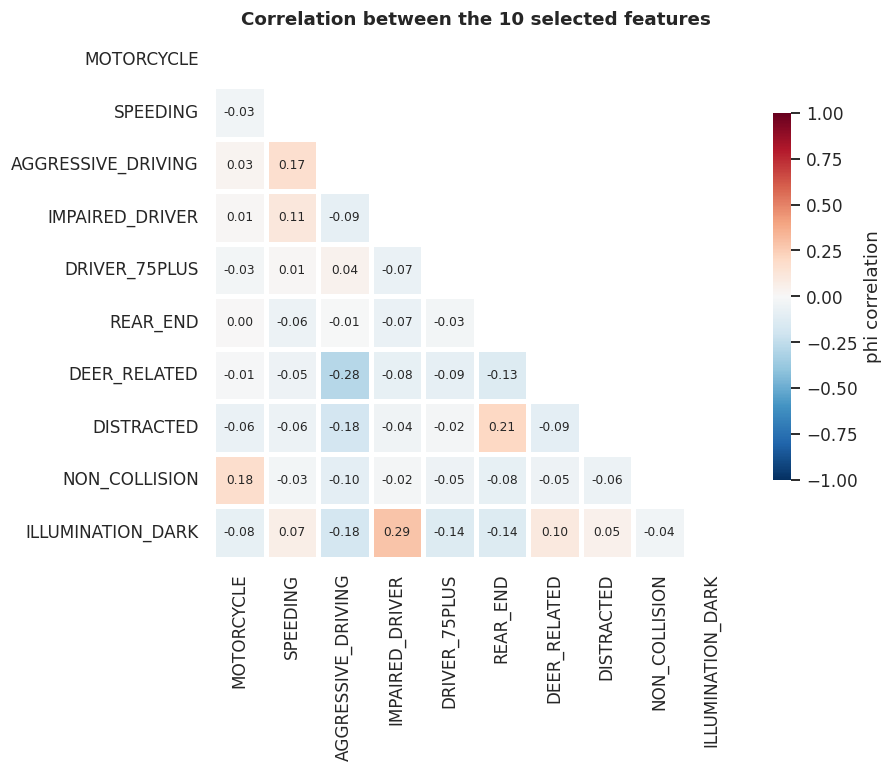

```
Largest absolute correlation: 0.29
```

```python
X_final = crash[FINAL].astype(float)
corr = X_final.corr()
fig, ax = plt.subplots(figsize=(8.5, 7))
mask = np.triu(np.ones_like(corr, dtype=bool))
sns.heatmap(corr, mask=mask, annot=True, fmt=".2f", cmap="RdBu_r", vmin=-1, vmax=1, center=0, square=True,
            linewidths=2, linecolor="white", cbar_kws={"shrink": 0.7, "label": "phi correlation"}, ax=ax,
            annot_kws={"fontsize": 8})
ax.set_title("Correlation between the 10 selected features"); ax.grid(False)
plt.tight_layout(); plt.show()
print(f"Largest absolute correlation: {corr.where(~np.eye(len(corr), dtype=bool)).abs().max().max():.2f}")
```

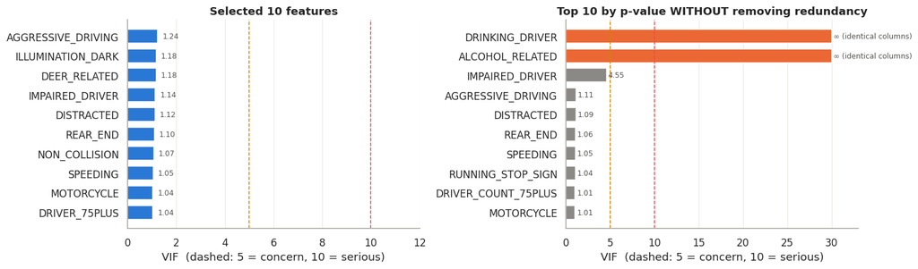

```python
def vif_table(cols):
    X = sm.add_constant(crash[cols].astype(float).fillna(crash[cols].mean()))
    return pd.Series([variance_inflation_factor(X.values, i) for i in range(1, X.shape[1])], index=cols)

naive = ["REAR_END", "MOTORCYCLE", "AGGRESSIVE_DRIVING", "SPEEDING", "DISTRACTED", "IMPAIRED_DRIVER",
         "DRINKING_DRIVER", "ALCOHOL_RELATED", "RUNNING_STOP_SIGN", "DRIVER_COUNT_75PLUS"]
v_final, v_naive = vif_table(FINAL), vif_table(naive)

fig, axes = plt.subplots(1, 2, figsize=(14, 4.2), sharex=False)
for ax, v, title, color in [(axes[0], v_final, "Selected 10 features", C_ALL),
                            (axes[1], v_naive.clip(upper=30), "Top 10 by p-value WITHOUT removing redundancy", C_GRAY)]:
    v = v.sort_values()
    ax.barh(v.index, v.values, color=[C_HI if x > 5 else color for x in v.values], edgecolor="white", height=0.7)
    for i, (name, x) in enumerate(v.items()):
        lbl = "∞ (identical columns)" if (title.startswith("Top") and v_naive[name] > 1e6) else f"{x:.2f}"
        ax.text(x + 0.2, i, lbl, va="center", fontsize=8, color="#52514e")
    ax.axvline(5, color="#c98500", lw=1, ls="--"); ax.axvline(10, color="#e34948", lw=1, ls="--")
    ax.set_title(title); ax.set_xlabel("VIF  (dashed: 5 = concern, 10 = serious)")
    ax.set_xlim(0, 33 if title.startswith("Top") else 12); ax.grid(axis="y", visible=False)
plt.tight_layout(); plt.show()
```

**Result:** every VIF for the selected 10 is close to 1 (the largest is ~1.24), and the largest correlation is 0.29, well below any warning level. That pair is `ILLUMINATION_DARK` with `IMPAIRED_DRIVER`, since impaired driving happens mostly at night. The model can separate each feature's effect. The naive set, without redundancy removal, contains identical columns (`ALCOHOL_RELATED` = `DRINKING_DRIVER`), whose VIF is infinite. The redundancy step in section 5 was necessary.

### 6a. Association tests: Pearson (continuous) and chi-square (categorical)

The correlation matrix and VIF above check the final model. As a second, pair-by-pair check, we also run the two association tests used for feature screening:

| Variable types | Test | Strength measure |
| --- | --- | --- |
| Two continuous / count variables | **Pearson correlation** | $r$ (from −1 to 1) |
| Two categorical (yes/no) variables | **Chi-square test** on their contingency table | **Cramér's V** (0 to 1; for two yes/no variables it equals \|phi\|) |

**How to read them.**

- The **p-value** answers *"is there any association?"*. The null hypothesis is that the two variables are **independent**. A small p-value (e.g. < 0.05) means they **are** associated; a large one means no association was detected. With hundreds of crashes, even a trivial link can be "significant".
- The **strength** ($|r|$ or V) answers *"are they so similar that one is redundant?"*. Decision rule: **above 0.8, drop one of the pair; 0.7–0.8 is marginal; below 0.7, keep both.**

So a pair can be significantly associated *and* still both be kept, as long as the association is weak.

```python
# Worked example: AGGRESSIVE_DRIVING x ALCOHOL_RELATED
from itertools import combinations
from scipy.stats import chi2_contingency, pearsonr

def assoc(a, b, d=crash):
    t = pd.crosstab(d[a], d[b])
    chi2, p, dof, expected = chi2_contingency(t, correction=False)
    v = np.sqrt(chi2 / (t.values.sum() * (min(t.shape) - 1)))
    p_exact = fisher_exact(t.values)[1] if t.shape == (2, 2) else np.nan
    return t, expected, chi2, p, v, p_exact

def verdict(s):
    return "Drop one (> 0.8)" if s > 0.8 else ("Marginal (0.7–0.8)" if s >= 0.7 else "Keep both (< 0.7)")

t, expected, chi2, p, v, _ = assoc("AGGRESSIVE_DRIVING", "ALCOHOL_RELATED")
lab = {0: "No", 1: "Yes"}
obs = t.rename(index=lab, columns=lab).rename_axis(index="Aggressive driving", columns="Alcohol related")
exp = pd.DataFrame(expected, index=obs.index, columns=obs.columns).round(1)
display(pd.concat({"Observed crashes": obs, "Expected if independent": exp}, axis=1)
          .style.set_caption("Contingency table: aggressive driving x alcohol"))
print(f"Chi-square = {chi2:.2f}, df = 1, p = {p:.3f}, Cramér's V = {v:.2f}")
print(f"→ p < 0.05: the two ARE associated (alcohol crashes are less often aggressive than independence predicts),")
print(f"  but V = {v:.2f} is far below 0.7, so the association is weak → {verdict(v).lower()}.")
```

Contingency table: aggressive driving x alcohol

| Alcohol related Aggressive driving | Observed crashes No | Observed crashes Yes | Expected if independent No | Expected if independent Yes |
| --- | --- | --- | --- | --- |
| No | 294 | 28 | 302.100000 | 19.900000 |
| Yes | 343 | 14 | 334.900000 | 22.100000 |

```
Chi-square = 6.65, df = 1, p = 0.010, Cramér's V = 0.10
→ p < 0.05: the two ARE associated (alcohol crashes are less often aggressive than independence predicts),
  but V = 0.10 is far below 0.7, so the association is weak → keep both (< 0.7).
```

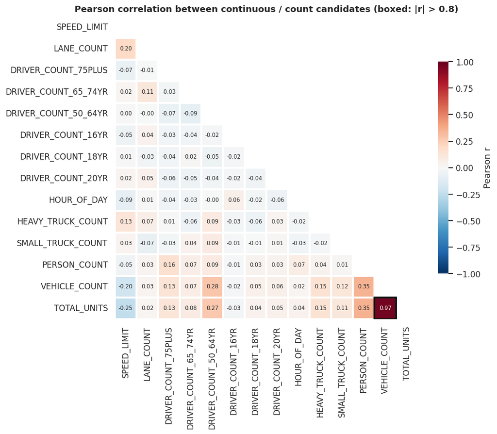

Strongest Pearson correlations

| Variable A | Variable B | r | p | Decision |
| --- | --- | --- | --- | --- |
| VEHICLE_COUNT | TOTAL_UNITS | 0.97 | 0 | Drop one (> 0.8) |
| PERSON_COUNT | TOTAL_UNITS | 0.35 | 2.5e-21 | Keep both (< 0.7) |
| PERSON_COUNT | VEHICLE_COUNT | 0.35 | 5.4e-21 | Keep both (< 0.7) |
| DRIVER_COUNT_50_64YR | VEHICLE_COUNT | 0.28 | 1.9e-13 | Keep both (< 0.7) |
| DRIVER_COUNT_50_64YR | TOTAL_UNITS | 0.27 | 1.8e-12 | Keep both (< 0.7) |
| SPEED_LIMIT | TOTAL_UNITS | -0.25 | 7.8e-11 | Keep both (< 0.7) |

```
91 pairs tested: 1 above 0.8, 0 marginal (0.7–0.8), the rest below 0.7.
```

```python
# Pearson correlation among the continuous / count candidates
NUMERIC = [c for c in CANDIDATES if not crash[c].dropna().isin([0, 1]).all()]
r = crash[NUMERIC].corr(method="pearson")
fig, ax = plt.subplots(figsize=(10, 8.2))
mask = np.triu(np.ones_like(r, dtype=bool))
sns.heatmap(r, mask=mask, annot=True, fmt=".2f", cmap="RdBu_r", vmin=-1, vmax=1, center=0, square=True,
            linewidths=1.5, linecolor="white", annot_kws={"fontsize": 7.5},
            cbar_kws={"shrink": 0.7, "label": "Pearson r"}, ax=ax)
for (i, j), val in np.ndenumerate(r.values):
    if i > j and abs(val) > 0.8:
        ax.add_patch(plt.Rectangle((j, i), 1, 1, fill=False, edgecolor="#0b0b0b", lw=2.5))
ax.set_title("Pearson correlation between continuous / count candidates (boxed: |r| > 0.8)"); ax.grid(False)
plt.tight_layout(); plt.show()

rows = []
for a, b in combinations(NUMERIC, 2):
    ok = crash[[a, b]].dropna()
    rr, pp = pearsonr(ok[a], ok[b])
    rows.append({"Variable A": a, "Variable B": b, "r": rr, "p": pp, "|r|": abs(rr), "Decision": verdict(abs(rr))})
pear = pd.DataFrame(rows).sort_values("|r|", ascending=False)
display(pear.head(6).drop(columns="|r|").style.format({"r": "{:.2f}", "p": "{:.2g}"}).hide(axis="index")
            .set_caption("Strongest Pearson correlations"))
print(f"{len(pear)} pairs tested: {int((pear['|r|'] > 0.8).sum())} above 0.8, "
      f"{int(pear['|r|'].between(0.7, 0.8).sum())} marginal (0.7–0.8), the rest below 0.7.")
```

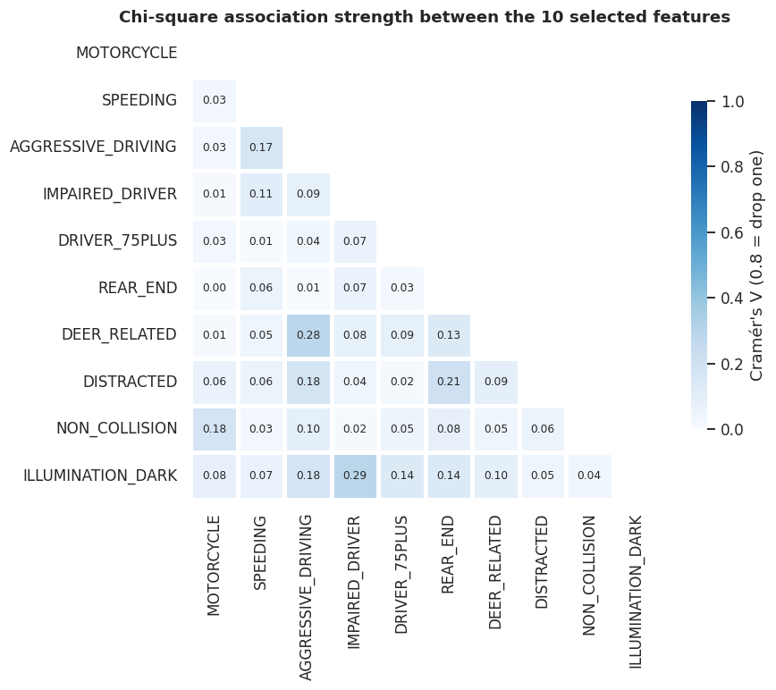

Ten strongest associations (shaded: expected count < 5, so trust the Fisher p-value)

| Feature A | Feature B | Chi-square | p (chi-square) | p (Fisher exact) | Smallest expected count | Cramér's V | Decision |
| --- | --- | --- | --- | --- | --- | --- | --- |
| IMPAIRED_DRIVER | ILLUMINATION_DARK | 55.7 | 8.6e-14 | 1.3e-11 | 12.7 | 0.29 | Keep both (< 0.7) |
| AGGRESSIVE_DRIVING | DEER_RELATED | 54.1 | 1.9e-13 | 1.1e-15 | 23.2 | 0.28 | Keep both (< 0.7) |
| REAR_END | DISTRACTED | 29.9 | 4.4e-08 | 8.1e-07 | 13.1 | 0.21 | Keep both (< 0.7) |
| AGGRESSIVE_DRIVING | DISTRACTED | 22.6 | 2e-06 | 1.9e-06 | 33.2 | 0.18 | Keep both (< 0.7) |
| MOTORCYCLE | NON_COLLISION | 18.5 | 1.7e-05 | 0.0028 | 0.6 | 0.18 | Keep both (< 0.7) |
| AGGRESSIVE_DRIVING | ILLUMINATION_DARK | 21.4 | 3.8e-06 | 4.1e-06 | 77.3 | 0.18 | Keep both (< 0.7) |
| SPEEDING | AGGRESSIVE_DRIVING | 18.6 | 1.6e-05 | 2.3e-06 | 9.5 | 0.17 | Keep both (< 0.7) |
| REAR_END | ILLUMINATION_DARK | 12.7 | 0.00036 | 0.00021 | 30.5 | 0.14 | Keep both (< 0.7) |
| DRIVER_75PLUS | ILLUMINATION_DARK | 12.7 | 0.00037 | 9.7e-05 | 14.2 | 0.14 | Keep both (< 0.7) |
| REAR_END | DEER_RELATED | 12.2 | 0.00049 | 3.6e-05 | 9.2 | 0.13 | Keep both (< 0.7) |

```
45 pairs: 19 significantly associated (p < 0.05), but the largest Cramér's V is 0.29. No pair is above 0.7 → keep all ten.
24 pairs have an expected count below 5, where the chi-square approximation is unreliable; for those, Fisher's exact test reaches the same p < 0.05 conclusion in 23 of 24 cases.
```

```python
# Chi-square + Cramér's V for every pair of the 10 selected (all yes/no) features
rows = []
for a, b in combinations(FINAL, 2):
    t, expected, chi2, p, v, p_exact = assoc(a, b)
    rows.append({"Feature A": a, "Feature B": b, "Chi-square": chi2, "p (chi-square)": p,
                 "p (Fisher exact)": p_exact, "Smallest expected count": expected.min(), "Cramér's V": v,
                 "Decision": verdict(v)})
chi = pd.DataFrame(rows).sort_values("Cramér's V", ascending=False)

V = pd.DataFrame(np.nan, index=FINAL, columns=FINAL)
for _, rw in chi.iterrows():
    V.loc[rw["Feature B"], rw["Feature A"]] = V.loc[rw["Feature A"], rw["Feature B"]] = rw["Cramér's V"]
fig, ax = plt.subplots(figsize=(8.5, 7))
sns.heatmap(V, mask=np.triu(np.ones_like(V, dtype=bool)), annot=True, fmt=".2f", cmap="Blues", vmin=0, vmax=1,
            square=True, linewidths=2, linecolor="white", annot_kws={"fontsize": 8},
            cbar_kws={"shrink": 0.7, "label": "Cramér's V (0.8 = drop one)"}, ax=ax)
ax.set_title("Chi-square association strength between the 10 selected features"); ax.grid(False)
plt.tight_layout(); plt.show()

display(chi.head(10).style.format({"Chi-square": "{:.1f}", "p (chi-square)": "{:.2g}", "p (Fisher exact)": "{:.2g}",
                                   "Smallest expected count": "{:.1f}", "Cramér's V": "{:.2f}"})
           .map(lambda v: "background-color: #fbe5d6" if v < 5 else "", subset=["Smallest expected count"])
           .hide(axis="index").set_caption("Ten strongest associations (shaded: expected count < 5, so trust the Fisher p-value)"))
n_sig = int((chi["p (chi-square)"] < 0.05).sum())
v_max = chi["Cramér's V"].max()
small = chi["Smallest expected count"] < 5
same = int(((chi["p (chi-square)"] < 0.05) == (chi["p (Fisher exact)"] < 0.05))[small].sum())
print(f"45 pairs: {n_sig} significantly associated (p < 0.05), but the largest Cramér's V is {v_max:.2f}. "
      f"No pair is above 0.7 → keep all ten.")
print(f"{int(small.sum())} pairs have an expected count below 5, where the chi-square approximation is unreliable; "
      f"for those, Fisher's exact test reaches the same p < 0.05 conclusion in {same} of {int(small.sum())} cases.")
```

```python
# The same tests applied to the redundant pairs removed in section 5
rows = []
for a, b in PAIRS:
    t, expected, chi2, p, v, _ = assoc(a, b)
    rows.append({"Flag A": a, "Flag B": b, "Chi-square": chi2, "p": p, "Cramér's V": v, "Decision": verdict(v)})
(pd.DataFrame(rows).style.format({"Chi-square": "{:.1f}", "p": "{:.2g}", "Cramér's V": "{:.2f}"})
   .map(lambda s: "font-weight: bold; color: #e34948" if s.startswith("Drop") else "", subset=["Decision"])
   .hide(axis="index").set_caption("Association tests for the related flags considered in section 5"))
```

Association tests for the related flags considered in section 5

| Flag A | Flag B | Chi-square | p | Cramér's V | Decision |
| --- | --- | --- | --- | --- | --- |
| DRINKING_DRIVER | ALCOHOL_RELATED | 679.0 | 1.1e-149 | 1.00 | Drop one (> 0.8) |
| DRINKING_DRIVER | IMPAIRED_DRIVER | 528.8 | 5.2e-117 | 0.88 | Drop one (> 0.8) |
| RUNNING_STOP_SIGN | AGGRESSIVE_DRIVING | 16.7 | 4.4e-05 | 0.16 | Keep both (< 0.7) |
| RUNNING_RED_LT | AGGRESSIVE_DRIVING | 22.4 | 2.2e-06 | 0.18 | Keep both (< 0.7) |
| SPEEDING | AGGRESSIVE_DRIVING | 18.6 | 1.6e-05 | 0.17 | Keep both (< 0.7) |
| SUDDEN_DEER | DEER_RELATED | 664.1 | 1.9e-146 | 0.99 | Drop one (> 0.8) |
| DRIVER_75PLUS | MATURE_DRIVER | 272.9 | 2.7e-61 | 0.63 | Keep both (< 0.7) |
| WORK_ZONE | WORK_ZONE_IND | 679.0 | 1.1e-149 | 1.00 | Drop one (> 0.8) |
| PEDESTRIAN | VULNERABLE_ROAD_USER | 496.3 | 6e-110 | 0.92 | Drop one (> 0.8) |

**Association-test results**

- **Pearson:** only `VEHICLE_COUNT` and `TOTAL_UNITS` exceed 0.8 (r ≈ 0.97: total units = vehicles + pedestrians/cyclists, almost the same number). One of them would have to go, but **neither is in the final ten** (crash geometry is captured more directly by the collision-type flags). Every other numeric pair is well below 0.7.
- **Chi-square among the final ten:** many pairs are *statistically* associated (p < 0.05), as expected for crash characteristics that co-occur. Examples: impaired driving with darkness, rear-ends with distraction. But every **Cramér's V is ≤ 0.29**, far below 0.7. Each feature carries distinct information, so **all ten are kept**, which agrees with the VIF result.
- **Redundant pairs from section 5:** the tests confirm those decisions. Five pairs have V above 0.8: `DRINKING_DRIVER` × `ALCOHOL_RELATED` (1.00), `WORK_ZONE` × `WORK_ZONE_IND` (1.00), `SUDDEN_DEER` × `DEER_RELATED` (0.99), `PEDESTRIAN` × `VULNERABLE_ROAD_USER` (0.92) and `DRINKING_DRIVER` × `IMPAIRED_DRIVER` (0.88). In each case only one flag, or neither, is in the final ten; we kept the umbrella flags `IMPAIRED_DRIVER` and `DEER_RELATED`. `DRIVER_75PLUS` × `MATURE_DRIVER` (0.63) is below the threshold, and only `DRIVER_75PLUS` was selected. The *subset* relationships (`RUNNING_STOP_SIGN` ⊂ `AGGRESSIVE_DRIVING`) have a low V, which is why they were removed for **nesting**, not for correlation: the overlap table in section 5 shows that 100% of stop-sign crashes are aggressive-driving crashes.
- **Small expected counts:** chi-square is unreliable when an expected cell count is below 5 (common for rare flags such as `MOTORCYCLE`). Fisher's exact test is reported alongside for those pairs.

## 7. Feature analysis

### 7a. How common and how dangerous is each factor, overall and on rural roads?

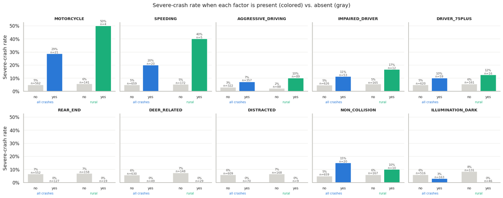

```python
fig, axes = plt.subplots(2, 5, figsize=(17, 6.6), sharey=True)
for ax, f in zip(axes.flat, FINAL):
    vals, labels, colors = [], [], []
    for scope, d, col in [("All", crash, C_ALL), ("Rural", rural_crash, C_RURAL)]:
        for flag in (0, 1):
            sub = d[d[f] == flag]
            vals.append(sub[TARGET].mean() if len(sub) else 0); labels.append(f"{scope}\n{'yes' if flag else 'no'}")
            colors.append(col if flag else "#d6d5d0")
    bars = ax.bar([0, 1, 2.6, 3.6], vals, color=colors, edgecolor="white", linewidth=1.5, width=0.85)
    for b, v, (scope, d) in zip(bars, vals, [("All", crash)] * 2 + [("Rural", rural_crash)] * 2):
        n = int((d[f] == (1 if b in bars[1::2] else 0)).sum())
        ax.text(b.get_x() + b.get_width() / 2, v + 0.004, f"{v:.0%}\nn={n}", ha="center", fontsize=7, color="#52514e")
    ax.set_xticks([0, 1, 2.6, 3.6], ["no", "yes", "no", "yes"], fontsize=8)
    ax.text(0.5, -0.17, "all crashes", transform=ax.get_xaxis_transform(), ha="center", fontsize=7.5, color=C_ALL)
    ax.text(3.1, -0.17, "rural", transform=ax.get_xaxis_transform(), ha="center", fontsize=7.5, color=C_RURAL)
    ax.set_title(f, fontsize=9.5); ax.grid(axis="x", visible=False)
    ax.yaxis.set_major_formatter(mtick.PercentFormatter(1, decimals=0))
for ax in axes[:, 0]:
    ax.set_ylabel("Severe-crash rate")
fig.suptitle("Severe-crash rate when each factor is present (colored) vs. absent (gray)", fontsize=13, y=1.0)
plt.tight_layout(); plt.show()
```

```python
prev = pd.DataFrame({
    "Share of rural crashes": rural_crash[FINAL].mean(),
    "Share of non-rural crashes": crash.loc[crash.RURAL == 0, FINAL].mean(),
    "Rural severe crashes with factor": [f"{int(((rural_crash[f] == 1) & (rural_crash[TARGET] == 1)).sum())} of {int(rural_crash[TARGET].sum())}" for f in FINAL]})
prev["Rural ÷ non-rural"] = prev["Share of rural crashes"] / prev["Share of non-rural crashes"]
(prev.style.format({"Share of rural crashes": "{:.1%}", "Share of non-rural crashes": "{:.1%}", "Rural ÷ non-rural": "{:.2f}×"})
     .background_gradient(cmap="Greens", subset=["Rural ÷ non-rural"], vmin=0.3, vmax=3)
     .set_caption("How often each factor appears in rural vs. non-rural crashes"))
```

How often each factor appears in rural vs. non-rural crashes

|  | Share of rural crashes | Share of non-rural crashes | Rural severe crashes with factor | Rural ÷ non-rural |
| --- | --- | --- | --- | --- |
| MOTORCYCLE | 2.8% | 3.9% | 2 of 11 | 0.71× |
| SPEEDING | 2.8% | 3.0% | 2 of 11 | 0.95× |
| AGGRESSIVE_DRIVING | 50.3% | 53.4% | 9 of 11 | 0.94× |
| IMPAIRED_DRIVER | 6.8% | 8.2% | 2 of 11 | 0.83× |
| DRIVER_75PLUS | 9.0% | 8.6% | 2 of 11 | 1.06× |
| REAR_END | 10.7% | 21.5% | 0 of 11 | 0.50× |
| DEER_RELATED | 16.4% | 4.0% | 0 of 11 | 4.11× |
| DISTRACTED | 5.1% | 12.2% | 0 of 11 | 0.42× |
| NON_COLLISION | 5.6% | 2.0% | 1 of 11 | 2.84× |
| ILLUMINATION_DARK | 26.0% | 23.3% | 0 of 11 | 1.12× |

**What stands out**

- **Deer crashes are distinctly rural.** About one in six rural crashes involves a deer, versus one in twenty-five elsewhere (4× more common), and none of them was severe. **Non-collision events** (rollovers, etc.), which raise severity, are also ~3× more common on rural roads.
- **The main risk factors are about as common on rural roads as elsewhere.** Aggressive driving appears in about half of all crashes in both settings, and impairment, speeding and drivers aged 75+ in similar shares. Rural crashes are not *more often* aggressive or impaired; those factors simply matter just as much there.
- **Rear-end and distraction crashes are about half as common on rural roads** (they come with traffic and congestion). They are the clearest low-severity markers, which helps explain why rural crashes are slightly more often severe (6.2% vs. 5.0%).

### 7b. Why is darkness *protective* here?

First principles say darkness should make crashes **more** severe, yet in this sample dark crashes are severe *less* often. The table below shows why:

```python
dark = crash.groupby(crash.ILLUMINATION_DARK.map({0: "Daylight / dusk / dawn", 1: "Dark"})).agg(
    Crashes=(TARGET, "size"), Severe=(TARGET, "sum"), Severe_rate=(TARGET, "mean"),
    Motorcycle=("MOTORCYCLE", "mean"), Single_vehicle=("SINGLE_VEHICLE", "mean"),
    Deer=("DEER_RELATED", "mean"), Impaired=("IMPAIRED_DRIVER", "mean"))
dark.style.format({"Severe_rate": "{:.1%}", "Motorcycle": "{:.1%}", "Single_vehicle": "{:.0%}", "Deer": "{:.0%}", "Impaired": "{:.0%}"}) \
    .set_caption("Crash mix in daylight vs. dark")
```

Crash mix in daylight vs. dark

| ILLUMINATION_DARK | Crashes | Severe | Severe_rate | Motorcycle | Single_vehicle | Deer | Impaired |
| --- | --- | --- | --- | --- | --- | --- | --- |
| Dark | 163 | 5.000000 | 3.1% | 0.7% | 65% | 12% | 21% |
| Daylight / dusk / dawn | 516 | 31.000000 | 6.0% | 4.5% | 37% | 6% | 3% |

In this sample, motorcycle crashes (the most dangerous type) **happen almost entirely in daylight** (4.5% of daylight crashes vs. 0.7% of dark ones), and dark crashes are twice as often **deer strikes** (12% vs. 6%, never severe here). Dark crashes are more often single-vehicle and impaired, but those did not outweigh the missing motorcycle crashes. Darkness itself is not protective: it marks a different **mix of crashes**. Even so, it is a useful *predictor*. The model keeps it, and we interpret it as "dark-condition crash types are less severe in this data", not as "darkness makes roads safer". With only 5 severe dark crashes, this pattern could also be chance.

## 8. The final model

**Setup**

- **Model:** logistic regression on the 10 selected features. Mean imputation for the few remaining gaps (only `MOTORCYCLE` has any) and standardization are both learned inside each training fold. A mild L2 penalty is used, because `REAR_END`, `DEER_RELATED` and `DISTRACTED` have **zero** severe crashes: an unpenalized model would push their coefficients to minus infinity.
- **Class imbalance:** only 5.3% of crashes are severe. A model that always predicts "not severe" scores **94.7% accuracy and an F1 of 0**, so we weight the classes (`class_weight="balanced"`).
- **Decision threshold:** the cut-off that converts a probability into a "severe" prediction is **tuned to maximize F1**. It is chosen *inside* each training fold (by an inner cross-validation), so the test fold never influences it.
- **Evaluation:** stratified 5-fold cross-validation, repeated 20 times (100 test folds). We report mean ± standard deviation for **all crashes** and for **rural crashes only**. With only 36 severe crashes, a single train/test split would be unreliable.

```python
def make_model(C=1.0):
    return make_pipeline(SimpleImputer(strategy="mean"), StandardScaler(),
                         LogisticRegression(C=C, class_weight="balanced", max_iter=5000))

def best_f1_threshold(y_true, prob):
    prec, rec, thr = precision_recall_curve(y_true, prob)
    f1 = 2 * prec * rec / np.clip(prec + rec, 1e-12, None)
    return thr[np.nanargmax(f1[:-1])]

def evaluate(cols, n_repeats=20, seed=42):
    # Repeated CV with a nested (inner-CV) F1-optimal threshold; returns per-fold metrics and out-of-fold probabilities
    X = crash[cols].astype(float).values
    outer = RepeatedStratifiedKFold(n_splits=5, n_repeats=n_repeats, random_state=seed)
    recs, oof = [], np.full((n_repeats, len(y)), np.nan)
    thresholds = []
    for k, (tr, te) in enumerate(outer.split(X, y)):
        inner_prob = cross_val_predict(make_model(), X[tr], y[tr], cv=StratifiedKFold(5, shuffle=True, random_state=k),
                                       method="predict_proba")[:, 1]
        thr = best_f1_threshold(y[tr], inner_prob); thresholds.append(thr)
        prob = make_model().fit(X[tr], y[tr]).predict_proba(X[te])[:, 1]
        oof[k // 5, te] = prob
        pred = (prob >= thr).astype(int)
        for scope, m in [("All crashes", np.ones(len(te), bool)), ("Rural crashes", is_rural[te])]:
            yt, yp, pp = y[te][m], pred[m], prob[m]
            recs.append({"scope": scope, "fold": k, "Accuracy": accuracy_score(yt, yp),
                         "Precision": precision_score(yt, yp, zero_division=0), "Recall": recall_score(yt, yp, zero_division=0),
                         "F1": f1_score(yt, yp, zero_division=0),
                         "ROC AUC": roc_auc_score(yt, pp) if 0 < yt.sum() < len(yt) else np.nan})
    return pd.DataFrame(recs), oof, np.array(thresholds)

folds, oof, thresholds = evaluate(FINAL)
print(f"Tuned decision threshold: median {np.median(thresholds):.2f} (range {thresholds.min():.2f}–{thresholds.max():.2f})")
```

```
Tuned decision threshold: median 0.75 (range 0.56–0.88)
```

```python
METRICS = ["Accuracy", "Precision", "Recall", "F1", "ROC AUC"]
summary = folds.groupby("scope")[METRICS].agg(["mean", "std"])
tbl = pd.DataFrame({m: [f"{summary.loc[s, (m, 'mean')]:.3f} ± {summary.loc[s, (m, 'std')]:.3f}" for s in summary.index]
                    for m in METRICS}, index=summary.index)
# Baseline: always predict "not severe"
base = {s: {"Accuracy": 1 - y[msk].mean(), "Precision": 0, "Recall": 0, "F1": 0, "ROC AUC": 0.5}
        for s, msk in [("All crashes", np.ones(len(y), bool)), ("Rural crashes", is_rural)]}
for s in base:
    tbl.loc[f"{s}: always predict 'not severe'"] = [f"{base[s][m]:.3f}" for m in METRICS]
tbl.style.set_caption("Final model: cross-validated performance (mean ± sd over 100 test folds)") \
   .apply(lambda r: ["color: #8a8986" if "always" in r.name else "font-weight: bold" for _ in r], axis=1)
```

Final model: cross-validated performance (mean ± sd over 100 test folds)

| scope | Accuracy | Precision | Recall | F1 | ROC AUC |
| --- | --- | --- | --- | --- | --- |
| All crashes | 0.900 ± 0.037 | 0.228 ± 0.150 | 0.284 ± 0.185 | 0.225 ± 0.119 | 0.761 ± 0.067 |
| Rural crashes | 0.898 ± 0.054 | 0.322 ± 0.321 | 0.413 ± 0.368 | 0.304 ± 0.250 | 0.841 ± 0.115 |
| All crashes: always predict 'not severe' | 0.947 | 0.000 | 0.000 | 0.000 | 0.500 |
| Rural crashes: always predict 'not severe' | 0.938 | 0.000 | 0.000 | 0.000 | 0.500 |

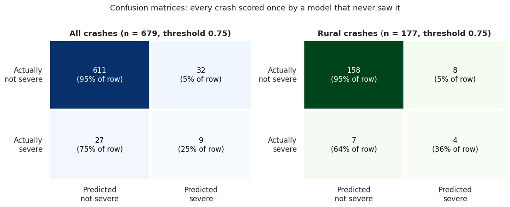

```python
# Pooled confusion matrices over one full repeat (every crash predicted exactly once)
prob0 = oof[0]
thr = np.median(thresholds)
pred0 = (prob0 >= thr).astype(int)
fig, axes = plt.subplots(1, 2, figsize=(11, 4.3))
for ax, (scope, m, cmap) in zip(axes, [("All crashes", np.ones(len(y), bool), "Blues"), ("Rural crashes", is_rural, "Greens")]):
    cm = confusion_matrix(y[m], pred0[m])
    sns.heatmap(cm, annot=False, cmap=cmap, cbar=False, ax=ax, linewidths=3, linecolor="white")
    for (i, j), v in np.ndenumerate(cm):
        ax.text(j + 0.5, i + 0.5, f"{v}\n({v / cm[i].sum():.0%} of row)", ha="center", va="center",
                fontsize=11, color="white" if v > cm.max() / 2 else "#0b0b0b")
    ax.set_xticklabels(["Predicted\nnot severe", "Predicted\nsevere"]); ax.set_yticklabels(["Actually\nnot severe", "Actually\nsevere"], rotation=0)
    ax.set_title(f"{scope} (n = {m.sum()}, threshold {thr:.2f})")
plt.suptitle("Confusion matrices: every crash scored once by a model that never saw it", y=1.02, fontsize=12)
plt.tight_layout(); plt.show()
```

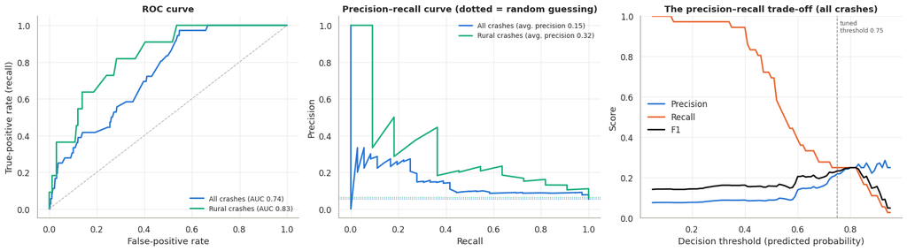

```python
fig, axes = plt.subplots(1, 3, figsize=(17, 4.8))
for scope, m, col in [("All crashes", np.ones(len(y), bool), C_ALL), ("Rural crashes", is_rural, C_RURAL)]:
    fpr, tpr, _ = roc_curve(y[m], oof[0][m])
    axes[0].plot(fpr, tpr, color=col, lw=2, label=f"{scope} (AUC {roc_auc_score(y[m], oof[0][m]):.2f})")
    prec, rec, _ = precision_recall_curve(y[m], oof[0][m])
    axes[1].plot(rec, prec, color=col, lw=2, label=f"{scope} (avg. precision {average_precision_score(y[m], oof[0][m]):.2f})")
    axes[1].axhline(y[m].mean(), color=col, lw=1, ls=":")
axes[0].plot([0, 1], [0, 1], color="#b5b4ae", ls="--", lw=1)
axes[0].set(xlabel="False-positive rate", ylabel="True-positive rate (recall)", title="ROC curve")
axes[1].set(xlabel="Recall", ylabel="Precision", title="Precision–recall curve (dotted = random guessing)")
for ax in axes[:2]:
    ax.legend(frameon=False, loc="lower right" if ax is axes[0] else "upper right", fontsize=9)

# Precision / recall / F1 vs. threshold
grid = np.linspace(0.05, 0.95, 91)
for name, fn, col in [("Precision", precision_score, C_ALL), ("Recall", recall_score, C_HI), ("F1", f1_score, "#0b0b0b")]:
    axes[2].plot(grid, [fn(y, (oof[0] >= t).astype(int), zero_division=0) for t in grid], color=col, lw=2, label=name)
axes[2].axvline(thr, color="#8a8986", ls="--", lw=1); axes[2].text(thr + 0.01, 0.92, f"tuned\nthreshold {thr:.2f}", fontsize=8, color="#52514e")
axes[2].set(xlabel="Decision threshold (predicted probability)", ylabel="Score", title="The precision–recall trade-off (all crashes)")
axes[2].legend(frameon=False); axes[2].set_ylim(0, 1)
plt.tight_layout(); plt.show()
```

### 8a. Is this the best 10? A comparison with alternatives

The same evaluation (identical folds, nested threshold) is run on four alternatives:

1. **All candidate features** (no selection, L2-penalized).
2. **Top 10 by filter p-value alone** (no first principles, no redundancy removal).
3. **The selected 10 with `ILLUMINATION_DARK` swapped for `LEFT_TURN`**, the next-best by overall p-value.
4. **The selected 10.**

*Caveat:* the selection itself used the full dataset, so the selected model's scores are slightly optimistic relative to brand-new data.

```python
ALL_CANDS = [c for c in CANDIDATES if c != "RURAL"]
alts = {"All candidate features": ALL_CANDS, "Top 10 by p-value only": naive,
        "Selected 10, darkness → left turn": [c if c != "ILLUMINATION_DARK" else "LEFT_TURN" for c in FINAL],
        "Selected 10": FINAL}
comp = []
for name, cols in alts.items():
    f_, _, _ = evaluate(cols) if name != "Selected 10" else (folds, None, None)   # same 100 folds for every model
    g = f_.groupby("scope")[METRICS].mean()
    for scope in g.index:
        comp.append({"Model": name, "Features": len(cols), "Scope": scope, **g.loc[scope].to_dict()})
comp = pd.DataFrame(comp)
comp_w = comp.pivot(index=["Model", "Features"], columns="Scope", values=["F1", "Recall", "Precision", "ROC AUC", "Accuracy"])
comp_w = comp_w.reindex(list(alts), level=0)
comp_w.style.format("{:.3f}").background_gradient(cmap="Blues", axis=0).set_caption("Selected model vs. alternatives (cross-validated means)")
```

Selected model vs. alternatives (cross-validated means)

| Model | Scope Features | F1 All crashes | F1 Rural crashes | Recall All crashes | Recall Rural crashes | Precision All crashes | Precision Rural crashes | ROC AUC All crashes | ROC AUC Rural crashes | Accuracy All crashes | Accuracy Rural crashes |
| --- | --- | --- | --- | --- | --- | --- | --- | --- | --- | --- | --- |
| All candidate features | 73 | 0.111 | 0.143 | 0.347 | 0.483 | 0.088 | 0.094 | 0.645 | 0.751 | 0.745 | 0.728 |
| Top 10 by p-value only | 10 | 0.159 | 0.208 | 0.205 | 0.266 | 0.181 | 0.236 | 0.709 | 0.780 | 0.897 | 0.893 |
| Selected 10, darkness → left turn | 10 | 0.201 | 0.239 | 0.243 | 0.307 | 0.216 | 0.277 | 0.741 | 0.789 | 0.902 | 0.893 |
| Selected 10 | 10 | 0.225 | 0.304 | 0.284 | 0.413 | 0.228 | 0.322 | 0.761 | 0.841 | 0.900 | 0.898 |

```python
fig = go.Figure()
order = list(alts)
for scope, col in [("All crashes", C_ALL), ("Rural crashes", C_RURAL)]:
    sub = comp[comp.Scope == scope].set_index("Model").loc[order]
    fig.add_trace(go.Bar(y=order, x=sub["ROC AUC"], name=f"ROC AUC · {scope}", orientation="h",
                         marker=dict(color=col, line=dict(color="white", width=1.5)),
                         hovertemplate="%{y}<br>" + scope + " ROC AUC: %{x:.3f}<extra></extra>"))
fig.update_layout(barmode="group", template="simple_white", height=380, title="Ranking quality (ROC AUC) of each feature set",
                  xaxis=dict(range=[0.5, 0.85], title="ROC AUC (0.5 = random)", showgrid=True, gridcolor="#ebeae6"),
                  legend=dict(orientation="h", y=-0.25, x=0.5, xanchor="center"), margin=dict(l=220))
fig.show()
```

[interactive chart not shown]

### 8b. Which factors matter most? Odds ratios from the final model

For interpretation we refit the 10-feature model on **all crashes** without class weights, keeping the mild L2 penalty (needed for the zero-severe flags), on the raw 0/1 features. Each **odds ratio** says how much the factor multiplies the odds of a severe outcome, **holding the other nine fixed**. The 95% intervals come from **1,000 bootstrap resamples** of crashes.

*Reading the protective flags:* `REAR_END`, `DEER_RELATED` and `DISTRACTED` have **zero** severe crashes. Their *direction* is certain in this data (no bootstrap resample ever puts them above 1), but their *size* is set mostly by the penalty: the data alone would push them to 0. Their narrow intervals reflect the penalty, not precise knowledge. Read them as "strongly protective", not as exact values.

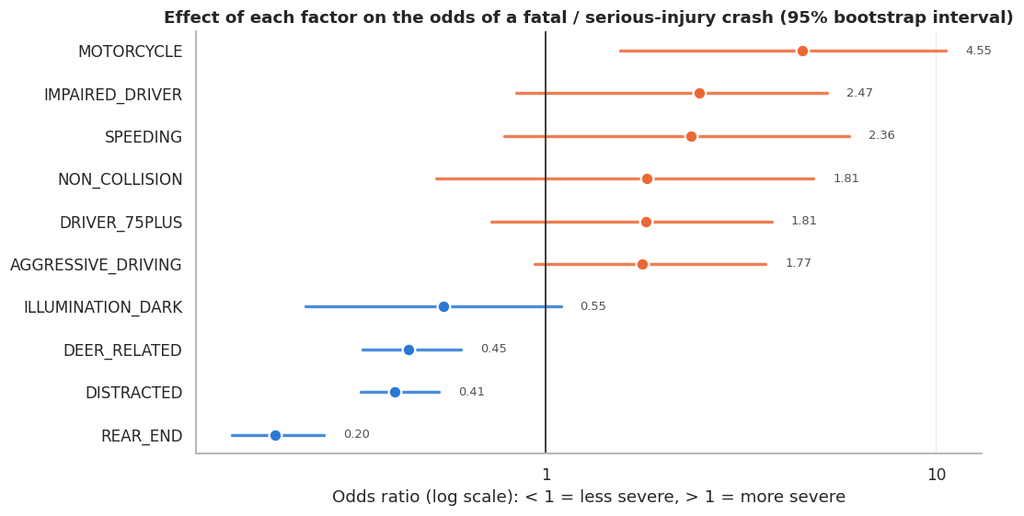

Penalized odds ratios (all crashes)

|  | Odds ratio | 95% CI low | 95% CI high | % of bootstraps with OR > 1 |
| --- | --- | --- | --- | --- |
| REAR_END | 0.20 | 0.16 | 0.27 | 0% |
| DISTRACTED | 0.41 | 0.34 | 0.53 | 0% |
| DEER_RELATED | 0.45 | 0.34 | 0.61 | 0% |
| ILLUMINATION_DARK | 0.55 | 0.24 | 1.09 | 4% |
| AGGRESSIVE_DRIVING | 1.77 | 0.94 | 3.66 | 96% |
| DRIVER_75PLUS | 1.81 | 0.72 | 3.79 | 90% |
| NON_COLLISION | 1.81 | 0.52 | 4.85 | 82% |
| SPEEDING | 2.36 | 0.78 | 5.98 | 94% |
| IMPAIRED_DRIVER | 2.47 | 0.84 | 5.25 | 96% |
| MOTORCYCLE | 4.55 | 1.55 | 10.60 | 100% |

```python
def fit_or(d):
    X = d[FINAL].astype(float).fillna(crash[FINAL].mean())
    m = LogisticRegression(C=1.0, max_iter=5000).fit(X, d[TARGET].astype(int))
    return pd.Series(np.exp(m.coef_[0]), index=FINAL)

rng = np.random.default_rng(0)
point = fit_or(crash)
boot = pd.DataFrame([fit_or(crash.iloc[rng.integers(0, len(crash), len(crash))]) for _ in range(1000)])
ors = pd.DataFrame({"Odds ratio": point, "95% CI low": boot.quantile(0.025), "95% CI high": boot.quantile(0.975),
                    "% of bootstraps with OR > 1": (boot > 1).mean()}).sort_values("Odds ratio")

fig, ax = plt.subplots(figsize=(10, 5.2))
for i, (f, r) in enumerate(ors.iterrows()):
    up = r["Odds ratio"] > 1
    col = C_HI if up else C_ALL
    ax.plot([r["95% CI low"], r["95% CI high"]], [i, i], color=col, lw=2.2, solid_capstyle="round", alpha=0.85)
    ax.scatter(r["Odds ratio"], i, s=80, color=col, edgecolor="white", linewidth=1.5, zorder=3)
    ax.text(r["95% CI high"] * 1.12, i, f"{r['Odds ratio']:.2f}", va="center", fontsize=8.5, color="#52514e")
ax.axvline(1, color="#0b0b0b", lw=1)
ax.set_xscale("log"); ax.xaxis.set_major_formatter(mtick.FuncFormatter(lambda v, _: f"{v:g}"))
ax.xaxis.set_minor_formatter(mtick.NullFormatter())
ax.set_yticks(range(len(ors)), ors.index); ax.grid(axis="y", visible=False)
ax.set_xlabel("Odds ratio (log scale): < 1 = less severe, > 1 = more severe")
ax.set_title("Effect of each factor on the odds of a fatal / serious-injury crash (95% bootstrap interval)")
plt.tight_layout(); plt.show()
ors.style.format({"Odds ratio": "{:.2f}", "95% CI low": "{:.2f}", "95% CI high": "{:.2f}", "% of bootstraps with OR > 1": "{:.0%}"}) \
   .background_gradient(cmap="RdBu_r", subset=["Odds ratio"], vmin=0, vmax=2) \
   .set_caption("Penalized odds ratios (all crashes)")
```

### 8c. What drives severe crashes *on rural roads*?

An odds ratio says how dangerous a factor is. How much it contributes to rural severe crashes also depends on **how often it occurs on rural roads**. The **population attributable fraction (PAF)** combines the two. Among the 11 severe rural crashes, it estimates the share that would not have been severe without the factor:

PAF = (share of severe rural crashes with the factor) × (OR − 1) / OR, for factors that raise risk (OR > 1).

With only 11 severe rural crashes these numbers are rough, but they show which factors matter in practice.

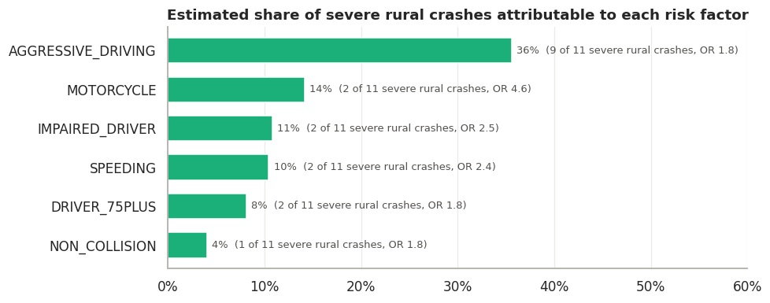

Rural contribution of each selected factor

|  | Odds ratio | Severe rural crashes with factor | Share of rural crashes with factor | PAF (rural) |
| --- | --- | --- | --- | --- |
| AGGRESSIVE_DRIVING | 1.77 | 9 | 50.3% | 36% |
| MOTORCYCLE | 4.55 | 2 | 2.8% | 14% |
| IMPAIRED_DRIVER | 2.47 | 2 | 6.8% | 11% |
| SPEEDING | 2.36 | 2 | 2.8% | 10% |
| DRIVER_75PLUS | 1.81 | 2 | 9.0% | 8% |
| NON_COLLISION | 1.81 | 1 | 5.6% | 4% |
| REAR_END | 0.20 | 0 | 10.7% | protective |
| DEER_RELATED | 0.45 | 0 | 16.4% | protective |
| DISTRACTED | 0.41 | 0 | 5.1% | protective |
| ILLUMINATION_DARK | 0.55 | 0 | 26.0% | protective |

```python
rs = rural_crash[rural_crash[TARGET] == 1]
paf = pd.DataFrame({"Odds ratio": point,
                    "Severe rural crashes with factor": rs[FINAL].sum().astype(int),
                    "Share of rural crashes with factor": rural_crash[FINAL].mean()})
paf["PAF (rural)"] = np.where(paf["Odds ratio"] > 1,
                              (paf["Severe rural crashes with factor"] / len(rs)) * (paf["Odds ratio"] - 1) / paf["Odds ratio"], np.nan)
paf = paf.sort_values("PAF (rural)", ascending=False)

risk = paf.dropna(subset=["PAF (rural)"])
fig, ax = plt.subplots(figsize=(9, 3.6))
ax.barh(risk.index[::-1], risk["PAF (rural)"][::-1], color=C_RURAL, edgecolor="white", height=0.65)
for i, (f, r) in enumerate(risk[::-1].iterrows()):
    ax.text(r["PAF (rural)"] + 0.005, i, f"{r['PAF (rural)']:.0%}  ({int(r['Severe rural crashes with factor'])} of {len(rs)} severe rural crashes, OR {r['Odds ratio']:.1f})",
            va="center", fontsize=8.5, color="#52514e")
ax.xaxis.set_major_formatter(mtick.PercentFormatter(1)); ax.set_xlim(0, max(0.6, risk["PAF (rural)"].max() * 1.6))
ax.set_title("Estimated share of severe rural crashes attributable to each risk factor"); ax.grid(axis="y", visible=False)
plt.tight_layout(); plt.show()
paf.style.format({"Odds ratio": "{:.2f}", "Share of rural crashes with factor": "{:.1%}", "PAF (rural)": "{:.0%}"}, na_rep="protective") \
   .set_caption("Rural contribution of each selected factor")
```

## 9. Conclusions

### The proposed 10 features

| Raises severity | Odds ratio (95% CI) | Lowers severity | Odds ratio |
| --- | --- | --- | --- |
| `MOTORCYCLE` | **4.6** (1.6–10.6) | `REAR_END` | 0.20 (0 of 127 severe) |
| `IMPAIRED_DRIVER` | 2.5 (0.8–5.3) | `DISTRACTED` | 0.41 (0 of 70 severe) |
| `SPEEDING` | 2.4 (0.8–6.0) | `DEER_RELATED` | 0.45 (0 of 49 severe) |
| `DRIVER_75PLUS` | 1.8 (0.7–3.8) | `ILLUMINATION_DARK` | 0.55 (crash-mix effect, see 7b) |
| `NON_COLLISION` | 1.8 (0.5–4.9) |  |  |
| `AGGRESSIVE_DRIVING` | 1.8 (0.9–3.7) |  |  |

### What contributes most to fatal / serious-injury crashes on rural roads

1. **Aggressive driving is the biggest contributor in practice.** It appears in half of all rural crashes and in **9 of the 11** severe rural crashes. By the attributable-fraction estimate, about **a third** of severe rural crashes are linked to it. Its effect per crash is moderate (~1.8× the odds), but it is very common.
2. **Motorcycles are the most dangerous single factor.** They raise the odds ~4.6×, and in rural crashes the severe rate jumps from 6% to 50% (2 of 4). Motorcycle crashes are rare, but when one happens on a rural road the rider has no protection at highway speeds.
3. **Impairment and speeding each raise the odds ~2.4×.** Both match first principles (slower reactions, more crash energy). Each accounts for roughly 10% of severe rural crashes.
4. **Drivers aged 75+ and non-collision events** (rollovers, mostly single-vehicle) each raise the odds ~1.8×. Non-collision crashes are **2.8× more common on rural roads** than elsewhere.
5. **What is *not* dangerous on rural roads:** deer strikes. They are **4× more common** in rural crashes (one in six), but **none** of the 49 was severe. Rear-ends and distraction crashes, both mostly non-rural, were also never severe. Dark-condition crashes were less severe, but because of *which* crashes happen in the dark (fewer motorcycles, more deer), not because darkness is safe.

### How good is the model?

|  | Accuracy | Precision | Recall | F1 | ROC AUC |
| --- | --- | --- | --- | --- | --- |
| **All crashes** | 0.900 | 0.228 | 0.284 | 0.225 | 0.761 |
| **Rural crashes** | 0.898 | 0.322 | 0.413 | 0.304 | 0.841 |
| *Always predict "not severe"* | *0.947* | *0* | *0* | *0* | *0.5* |

- **Accuracy is the wrong yardstick here.** A model that never predicts a severe crash scores 94.7% accuracy and catches nothing. Our model gives up some accuracy (90%) to find about **28% of severe crashes overall and ~41% on rural roads**. Roughly 1 in 4 of its "severe" flags is correct, which is 4–5× better than random guessing (5%).
- **It ranks crashes well**, especially on rural roads (AUC 0.84): a severe rural crash usually scores higher than a non-severe one.
- **The selected 10 beat every alternative tested.** All 73 candidates: AUC 0.65, F1 0.11. The top 10 by p-value alone: AUC 0.71, F1 0.16. This supports combining first principles with the filter rather than relying on statistics alone.

### Limitations: read these before acting on the results

- **Very few severe crashes:** 36 in total and only 11 on rural roads. Only `MOTORCYCLE` has an interval that clearly excludes "no effect"; `AGGRESSIVE_DRIVING` and `IMPAIRED_DRIVER` are borderline. Rural metrics swing widely between folds (F1 ± 0.25).
- **Slightly optimistic scores:** the features were chosen using the full dataset, so performance on brand-new data will probably be a little lower.
- **Association, not causation**, especially for darkness (section 7b) and the zero-severe flags.
- **Important variables are missing from this extract:** seat-belt use, curves, head-on risk on undivided two-lane roads, and distance to a trauma center. First principles and the wider literature rank these among the main rural severity factors.
- **Data cleaning mattered:** 30% of the rows were duplicate records of the same crash (one per road involved). Without collapsing them, the model would be tested on crashes it had already seen.

**Next step:** repeat this analysis on several years of PennDOT data (thousands of rural severe crashes). Include `UNBELTED`, `CURVED_ROAD` and `HO_OPPDIR_SDSWP`, and fit a rural-only model to confirm these factors.